# apartments_sale

### Предобработка данных

#### Удаление пропусков

Выведем количество пропущенных значений для каждого столбца.

```python
data.isna().sum()
```

```
total_images                0
last_price                  0
total_area                  0
first_day_exposition        0
rooms                       0
ceiling_height           9195
floors_total               86
living_area              1903
floor                       0
is_apartment            20924
studio                      0
open_plan                   0
kitchen_area             2278
balcony                 11519
locality_name              49
airports_nearest         5542
cityCenters_nearest      5519
parks_around3000         5518
parks_nearest           15620
ponds_around3000         5518
ponds_nearest           14589
days_exposition          3181
dtype: int64
```

Заполним пропущенные значения там, где это возможно. Для этого изучим каждый столбец в отдельности, посмотрим какие данные и в каком количестве они содержат.

Обратим внимание на столбцы с минимальным количеством пропусков - это `floors_total` - всего этажей в доме и `locality_name` - название населённого пункта. Восстановить эти данные нам вряд ли удастся. Поскольку пропущенных значений очень мало по сравнению со всем датафреймом, удалим строки с пропусками в этих столбцах.

```python
data = data.dropna(subset=['floors_total', 'locality_name'])
```

Посмотрим какие значения и в каком количестве хранит в себе столбец `is_apartment` - апартаменты (булев тип).

```python
data['is_apartment'].value_counts()
```

```
False    2710
True       50
Name: is_apartment, dtype: int64
```

Столбец `is_apartment` - содержит только булевые значения True и False. Вероятнее всего, пропущенные значения - это квартиры не относящиеся к апартаментам, поэтому заполним все пропущенные значения на False.

```python
data['is_apartment'] = data['is_apartment'].fillna(False)
```

Посмотрим какие значения и в каком количестве хранит в себе столбец `balcony` - число балконов.

```python
data['balcony'].value_counts()
```

```
1.0    4187
0.0    3680
2.0    3656
5.0     304
4.0     182
3.0      81
Name: balcony, dtype: int64
```

Если продавец не указал число балконов, то, скорее всего, в его квартире их нет. Такие пропуски заменим на 0.

```python
data['balcony'] = data['balcony'].fillna(0)
```

Посмотрим какие значения и в каком количестве хранят в себе столбцы `parks_around3000` и `ponds_around3000` - число парков и водоемов в радиусе 3 км.

```python
data['parks_around3000'].value_counts()
```

```
0.0    10039
1.0     5647
2.0     1736
3.0      643
Name: parks_around3000, dtype: int64
```

```python
data['ponds_around3000'].value_counts()
```

```
0.0    9029
1.0    5662
2.0    1883
3.0    1491
Name: ponds_around3000, dtype: int64
```

Предположим, что пропущенные значения - это отсутствие парка или водоема в радиусе 3 км. Заменим все пропуски в этих столбцах на 0.

```python
data['parks_around3000'] = data['parks_around3000'].fillna(0)
```

```python
data['ponds_around3000'] = data['ponds_around3000'].fillna(0)
```

Пропуски в столбцах `ceiling_height`, `living_area` и `kitchen_area` можно заполнить медианным значением по каждому типу данных из столбца `rooms` - число комнат.

```python
# пропуски в столбце 'ceiling_height' заполним медианными значениями в зависимости на количества комнат
warnings.simplefilter("ignore")
for t in data['rooms'].unique():
    data.loc[(data['rooms'] == t) & (data['ceiling_height'].isna()), 'ceiling_height'] = \
    data.loc[(data['rooms'] == t), 'ceiling_height'].median()
# оставшиеся пропуски заполним медианным значением этого столбца
data['ceiling_height'] = data['ceiling_height'].fillna(data['ceiling_height'].median())
```

Изменим алгоритм заполнения пропусков в столбце 'living_area' и 'kitchen_area'.

```python
# заполним пропуски в столбце living_area, исходя из общей площади
data['living_area'] = data['living_area'].fillna((0.85*data['total_area'])-data['kitchen_area'])
```

```python
# проверим количество пропусков
data['living_area'].isna().sum()
```

```
1427
```

```python
# заполним пропуски в столбце kitchen_area, исходя из общей площади
data['kitchen_area'] = data['kitchen_area'].fillna((0.85*data['total_area']) - data['living_area'])
```

```python
# проверим количество пропусков
data['kitchen_area'].isna().sum()
```

```
1427
```

Для 1427 строк нет данных не для жилой площади, не для площади кухни. Заполним оставшиеся пропуски в этих столбцах, исходя из общей площади.

```python
data['living_area'] = data['living_area'].fillna(0.7*data['total_area'])
```

```python
data['kitchen_area'] = data['kitchen_area'].fillna((0.85*data['total_area']) - data['living_area'])
```

Проверим условие - (total_area*0.9 <= (living_area + kitchen_area))

```python
data.query('total_area*0.9 <= (living_area + kitchen_area)')
```

|  | total_images | last_price | total_area | first_day_exposition | rooms | ceiling_height | floors_total | living_area | floor | is_apartment | ... | kitchen_area | balcony | locality_name | airports_nearest | cityCenters_nearest | parks_around3000 | parks_nearest | ponds_around3000 | ponds_nearest | days_exposition |
| --- | --- | --- | --- | --- | --- | --- | --- | --- | --- | --- | --- | --- | --- | --- | --- | --- | --- | --- | --- | --- | --- |
| 41 | 16 | 7900000.0 | 74.0 | 2016-05-04T00:00:00 | 3 | 2.65 | 14.0 | 59.0 | 8 | False | ... | 12.0 | 5.0 | Санкт-Петербург | 37715.0 | 12612.0 | 1.0 | 725.0 | 1.0 | 759.0 | 179.0 |
| 171 | 6 | 3800000.0 | 49.0 | 2019-02-22T00:00:00 | 2 | 2.50 | 9.0 | 38.0 | 8 | False | ... | 10.0 | 1.0 | посёлок Шушары | 18471.0 | 24272.0 | 0.0 | NaN | 0.0 | NaN | 11.0 |
| 184 | 7 | 2600000.0 | 30.2 | 2018-02-14T00:00:00 | 1 | 2.65 | 9.0 | 26.1 | 5 | False | ... | 6.2 | 0.0 | Санкт-Петербург | 13952.0 | 15031.0 | 0.0 | NaN | 1.0 | 824.0 | 12.0 |
| 220 | 8 | 3890000.0 | 37.0 | 2018-07-09T00:00:00 | 1 | 2.50 | 25.0 | 28.0 | 6 | False | ... | 9.0 | 0.0 | Санкт-Петербург | 25408.0 | 16166.0 | 0.0 | NaN | 0.0 | NaN | 28.0 |
| 319 | 19 | 4850000.0 | 59.7 | 2015-03-19T00:00:00 | 3 | 2.50 | 5.0 | 47.4 | 4 | False | ... | 6.4 | 1.0 | Санкт-Петербург | 43095.0 | 15599.0 | 0.0 | NaN | 0.0 | NaN | 974.0 |
| ... | ... | ... | ... | ... | ... | ... | ... | ... | ... | ... | ... | ... | ... | ... | ... | ... | ... | ... | ... | ... | ... |
| 23216 | 15 | 10150000.0 | 114.0 | 2015-01-21T00:00:00 | 4 | 2.80 | 5.0 | 90.2 | 4 | False | ... | 16.0 | 0.0 | Санкт-Петербург | 26259.0 | 4961.0 | 0.0 | NaN | 2.0 | 838.0 | 1052.0 |
| 23297 | 10 | 1850000.0 | 48.2 | 2019-03-13T00:00:00 | 2 | 2.60 | 5.0 | 42.2 | 2 | False | ... | 6.0 | 1.0 | Высоцк | NaN | NaN | 0.0 | NaN | 0.0 | NaN | 45.0 |
| 23328 | 12 | 4299000.0 | 54.0 | 2016-11-25T00:00:00 | 2 | 2.60 | 14.0 | 40.0 | 8 | False | ... | 10.0 | 0.0 | Колпино | 25612.0 | 31399.0 | 0.0 | NaN | 0.0 | NaN | 343.0 |
| 23521 | 13 | 8500000.0 | 65.0 | 2018-11-01T00:00:00 | 2 | 2.60 | 4.0 | 44.0 | 2 | False | ... | 15.3 | 0.0 | Санкт-Петербург | 22276.0 | 3996.0 | 1.0 | 627.0 | 0.0 | NaN | NaN |
| 23680 | 14 | 5000000.0 | 59.0 | 2019-04-04T00:00:00 | 3 | 2.50 | 5.0 | 52.0 | 1 | False | ... | 7.0 | 0.0 | Санкт-Петербург | 26835.0 | 11878.0 | 0.0 | NaN | 0.0 | NaN | NaN |

474 rows × 22 columns

Можем сделать вывод, что в исходных данных уже были строки не попадающие под это условие.

Проверим, на сколько нам удалось заполнить пропуски в столбцах.

```python
data.isna().sum()
```

```
total_images                0
last_price                  0
total_area                  0
first_day_exposition        0
rooms                       0
ceiling_height              0
floors_total                0
living_area                 0
floor                       0
is_apartment                0
studio                      0
open_plan                   0
kitchen_area                0
balcony                     0
locality_name               0
airports_nearest         5524
cityCenters_nearest      5501
parks_around3000            0
parks_nearest           15535
ponds_around3000            0
ponds_nearest           14529
days_exposition          3171
dtype: int64
```

Столбец `days_exposition` - сколько дней было размещено объявление (от публикации до снятия), если количество дней не указано, можно предположить, что объявление еще "висит". Поэтому пропуски в этом столбце заполнить не удастся.

Столбцы `airports_nearest`, `cityCenters_nearest`, `parks_nearest`, `ponds_nearest` - заполним медианными значениями по каждому типу из столбца `locality_name`. Но, для этого сначала изучим данные столбца `locality_name`.

```python
# check
data.info()
```

```
<class 'pandas.core.frame.DataFrame'>
Int64Index: 23565 entries, 0 to 23698
Data columns (total 22 columns):
 #   Column                Non-Null Count  Dtype
---  ------                --------------  -----
 0   total_images          23565 non-null  int64
 1   last_price            23565 non-null  float64
 2   total_area            23565 non-null  float64
 3   first_day_exposition  23565 non-null  object
 4   rooms                 23565 non-null  int64
 5   ceiling_height        23565 non-null  float64
 6   floors_total          23565 non-null  float64
 7   living_area           23565 non-null  float64
 8   floor                 23565 non-null  int64
 9   is_apartment          23565 non-null  bool
 10  studio                23565 non-null  bool
 11  open_plan             23565 non-null  bool
 12  kitchen_area          23565 non-null  float64
 13  balcony               23565 non-null  float64
 14  locality_name         23565 non-null  object
 15  airports_nearest      18041 non-null  float64
 16  cityCenters_nearest   18064 non-null  float64
 17  parks_around3000      23565 non-null  float64
 18  parks_nearest         8030 non-null   float64
 19  ponds_around3000      23565 non-null  float64
 20  ponds_nearest         9036 non-null   float64
 21  days_exposition       20394 non-null  float64
dtypes: bool(3), float64(14), int64(3), object(2)
memory usage: 3.7+ MB
```

#### Обработка дубликатов

Выведем перечень уникальных значений столбца `locality_name` - название населённого пункта.

```python
data['locality_name'].unique()
```

```
array(['Санкт-Петербург', 'посёлок Шушары', 'городской посёлок Янино-1',
       'посёлок Парголово', 'посёлок Мурино', 'Ломоносов', 'Сертолово',
       'Петергоф', 'Пушкин', 'деревня Кудрово', 'Коммунар', 'Колпино',
       'поселок городского типа Красный Бор', 'Гатчина', 'поселок Мурино',
       'деревня Фёдоровское', 'Выборг', 'Кронштадт', 'Кировск',
       'деревня Новое Девяткино', 'посёлок Металлострой',
       'посёлок городского типа Лебяжье',
       'посёлок городского типа Сиверский', 'поселок Молодцово',
       'поселок городского типа Кузьмоловский',
       'садовое товарищество Новая Ропша', 'Павловск',
       'деревня Пикколово', 'Всеволожск', 'Волхов', 'Кингисепп',
       'Приозерск', 'Сестрорецк', 'деревня Куттузи', 'посёлок Аннино',
       'поселок городского типа Ефимовский', 'посёлок Плодовое',
       'деревня Заклинье', 'поселок Торковичи', 'поселок Первомайское',
       'Красное Село', 'посёлок Понтонный', 'Сясьстрой', 'деревня Старая',
       'деревня Лесколово', 'посёлок Новый Свет', 'Сланцы',
       'село Путилово', 'Ивангород', 'Мурино', 'Шлиссельбург',
       'Никольское', 'Зеленогорск', 'Сосновый Бор', 'поселок Новый Свет',
       'деревня Оржицы', 'деревня Кальтино', 'Кудрово',
       'поселок Романовка', 'посёлок Бугры', 'поселок Бугры',
       'поселок городского типа Рощино', 'Кириши', 'Луга', 'Волосово',
       'Отрадное', 'село Павлово', 'поселок Оредеж', 'село Копорье',
       'посёлок городского типа Красный Бор', 'посёлок Молодёжное',
       'Тихвин', 'посёлок Победа', 'деревня Нурма',
       'поселок городского типа Синявино', 'Тосно',
       'посёлок городского типа Кузьмоловский', 'посёлок Стрельна',
       'Бокситогорск', 'посёлок Александровская', 'деревня Лопухинка',
       'Пикалёво', 'поселок Терволово',
       'поселок городского типа Советский', 'Подпорожье',
       'посёлок Петровское', 'посёлок городского типа Токсово',
       'поселок Сельцо', 'посёлок городского типа Вырица',
       'деревня Кипень', 'деревня Келози', 'деревня Вартемяги',
       'посёлок Тельмана', 'поселок Севастьяново',
       'городской поселок Большая Ижора', 'городской посёлок Павлово',
       'деревня Агалатово', 'посёлок Новогорелово',
       'городской посёлок Лесогорский', 'деревня Лаголово',
       'поселок Цвелодубово', 'поселок городского типа Рахья',
       'поселок городского типа Вырица', 'деревня Белогорка',
       'поселок Заводской', 'городской посёлок Новоселье',
       'деревня Большие Колпаны', 'деревня Горбунки', 'деревня Батово',
```

[output cut: 92 more lines]

```
       'поселок городского типа Токсово', 'посёлок Шугозеро',
       'деревня Ваганово', 'поселок Пушное', 'садовое товарищество Садко',
       'посёлок Усть-Ижора', 'деревня Выскатка',
       'городской посёлок Свирьстрой', 'поселок Громово',
       'деревня Кисельня', 'посёлок Старая Малукса',
       'деревня Трубников Бор', 'поселок Калитино',
       'посёлок Высокоключевой', 'садовое товарищество Приладожский',
       'посёлок Пансионат Зелёный Бор', 'деревня Ненимяки',
       'поселок Пансионат Зелёный Бор', 'деревня Снегирёвка',
       'деревня Рапполово', 'деревня Пустынка', 'поселок Рабитицы',
       'деревня Большой Сабск', 'деревня Русско', 'деревня Лупполово',
       'деревня Большое Рейзино', 'деревня Малая Романовка',
       'поселок Дружноселье', 'поселок Пчевжа', 'поселок Володарское',
       'деревня Нижняя', 'коттеджный посёлок Лесное', 'деревня Тихковицы',
       'деревня Борисова Грива', 'посёлок Дзержинского'], dtype=object)
```

Удалим неявные дубликаты, для этого уберем типы населенных пунктов, и оставим только их названия.

```python
# создадим список типов названия населенных пунктов в переменной
locality_type = ['посёлок', 'поселок', 'городской посёлок', 'городской поселок', 'деревня', \
                 'поселок городского типа', 'посёлок городского типа', 'садовое товарищество', \
                 'село', 'поселок станции', 'садоводческое некоммерческое товарищество', \
                 'посёлок при железнодорожной станции', 'коттеджный поселок', 'коттеджный посёлок', \
                 'городского типа', 'городской', 'при железнодорожной станции', 'коттеджный', 'станции']
# создадим цикл для перебора значений в списке:
for name in locality_type:
    data['locality_name'] = data['locality_name'].str.replace(name, '').str.strip()
```

```python
# проверим, что в столбце 'locality_name' остались только названия населенных пунктов
data['locality_name'].unique()
```

```
array(['Санкт-Петербург', 'Шушары', 'Янино-1', 'Парголово', 'Мурино',
       'Ломоносов', 'Сертолово', 'Петергоф', 'Пушкин', 'Кудрово',
       'Коммунар', 'Колпино', 'Красный Бор', 'Гатчина', 'Фёдоровское',
       'Выборг', 'Кронштадт', 'Кировск', 'Новое Девяткино',
       'Металлострой', 'Лебяжье', 'Сиверский', 'Молодцово',
       'Кузьмоловский', 'Новая Ропша', 'Павловск', 'Пикколово',
       'Всеволожск', 'Волхов', 'Кингисепп', 'Приозерск', 'Сестрорецк',
       'Куттузи', 'Аннино', 'Ефимовский', 'Плодовое', 'Заклинье',
       'Торковичи', 'Первомайское', 'Красное Село', 'Понтонный',
       'Сясьстрой', 'Старая', 'Лесколово', 'Новый Свет', 'Сланцы',
       'Путилово', 'Ивангород', 'Шлиссельбург', 'Никольское',
       'Зеленогорск', 'Сосновый Бор', 'Оржицы', 'Кальтино', 'Романовка',
       'Бугры', 'Рощино', 'Кириши', 'Луга', 'Волосово', 'Отрадное',
       'Павлово', 'Оредеж', 'Копорье', 'Молодёжное', 'Тихвин', 'Победа',
       'Нурма', 'Синявино', 'Тосно', 'Стрельна', 'Бокситогорск',
       'Александровская', 'Лопухинка', 'Пикалёво', 'Терволово',
       'Советский', 'Подпорожье', 'Петровское', 'Токсово', 'Сельцо',
       'Вырица', 'Кипень', 'Келози', 'Вартемяги', 'Тельмана',
       'Севастьяново', 'Большая Ижора', 'Агалатово', 'Новогорелово',
       'Лесогорский', 'Лаголово', 'Цвелодубово', 'Рахья', 'Белогорка',
       'Заводской', 'Новоселье', 'Большие Колпаны', 'Горбунки', 'Батово',
       'Заневка', 'Иссад', 'Приморск', 'Мистолово', 'Новая Ладога',
       'Зимитицы', 'Барышево', 'Разметелево', 'имени Свердлова', 'Пеники',
       'Рябово', 'Пудомяги', 'Корнево', 'Низино', 'Бегуницы', 'Поляны',
       'Мга', 'Елизаветино', 'Кузнечное', 'Колтуши', 'Запорожское',
       'Гостилицы', 'Малое Карлино', 'Мичуринское', 'имени Морозова',
       'Песочный', 'Сосново', 'Аро', 'Ильичёво', 'Тайцы', 'Малое Верево',
       'Извара', 'Вещево', 'Паша', 'Калитино', 'Ульяновка', 'Чудской Бор',
       'Дубровка', 'Мины', 'Войсковицы', 'Коркино', 'Ропша',
       'Приладожский', 'Щеглово', 'Гаврилово', 'Лодейное Поле',
       'Рабитицы', 'Никольский', 'Кузьмолово', 'Малые Колпаны',
       'Петро-Славянка', 'Назия', 'Репино', 'Углово', 'Старая Малукса',
       'Меньково', 'Старые Бегуницы', 'Сапёрный', 'Семрино', 'Глажево',
       'Кобринское', 'Гарболово', 'Юкки', 'Приветнинское', 'Мануйлово',
       'Пчева', 'Цвылёво', 'Мельниково', 'Пудость', 'Усть-Луга',
       'Светогорск', 'Любань', 'Селезнёво', 'Каменногорск', 'Кривко',
       'Глебычево', 'Парицы', 'Жил', 'Войскорово', 'Стеклянный', 'Важины',
       'Мыза-Ивановка', 'Русско-Высоцкое', 'Форносово', 'Старая Ладога',
       'Житково', 'Виллози', 'Лампово', 'Шпаньково', 'Лаврики', 'Сумино',
       'Возрождение', 'Старосиверская', 'Кикерино', 'Старое Хинколово',
```

[output cut: 10 more lines]

```
       'Разбегаево', 'Гладкое', 'Тёсово-4', 'Бор', 'Коробицыно',
       'Большая Вруда', 'Курковицы', 'Кобралово', 'Суоранда',
       'Кондратьево', 'Счастье', 'Реброво', 'Тойворово', 'Семиозерье',
       'Лесное', 'Совхозный', 'Ленинское', 'Суйда', 'Нижние Осельки',
       'Свирь', 'Перово', 'Высоцк', 'Шум', 'Котельский', 'Лужайка',
       'Большая Пустомержа', 'Красносельское', 'Вахнова Кара', 'Пижма',
       'Кивеннапа Север', 'Ромашки', 'Каськово', 'Куровицы', 'Плоское',
       'Кирпичное', 'Ям-Тесово', 'Раздолье', 'Терпилицы', 'Шугозеро',
       'Ваганово', 'Пушное', 'Садко', 'Усть-Ижора', 'Выскатка',
       'Свирьстрой', 'Кисельня', 'Трубников Бор', 'Высокоключевой',
       'Пансионат Зелёный Бор', 'Ненимяки', 'Снегирёвка', 'Рапполово',
       'Пустынка', 'Большой Сабск', 'Русско', 'Лупполово',
       'Большое Рейзино', 'Малая Романовка', 'Дружноселье', 'Пчевжа',
       'Володарское', 'Нижняя', 'Тихковицы', 'Борисова Грива',
       'Дзержинского'], dtype=object)
```

```python
# check
data['locality_name'].nunique()
```

```
305
```

#### Удаление пропусков (продолжение)

Столбцы `airports_nearest`, `parks_nearest`, `ponds_nearest` - заполним медианными значениями по каждому типу из столбца `locality_name`.

```python
# пропуски в столбце 'airports_nearest' заполним медианными значениями в зависимости на населенного пункта
warnings.simplefilter("ignore")
for t in data['locality_name'].unique():
    data.loc[(data['locality_name'] == t) & (data['airports_nearest'].isna()), 'airports_nearest'] = \
    data.loc[(data['locality_name'] == t), 'airports_nearest'].median()
```

```python
# проверим сколько пропусков осталось в столбце 'airports_nearest'
data['airports_nearest'].isna().sum()
```

```
5432
```

```python
# остальные пропуски заполним медианным значение столбца 'airports_nearest'
data['airports_nearest'] = data['airports_nearest'].fillna(data['airports_nearest'].median())
data['airports_nearest'].isna().sum()
```

```
0
```

Изучим распределение пропусков по городам в столбце 'cityCenters_nearest'.

```python
# создадим новую таблицу
data_centers_nearest = data[['locality_name', 'cityCenters_nearest']]
# создадим список, где строкам с "NaN" соответствует значение True
data_centers_nearest['cityCenters_nearest'] = data_centers_nearest['cityCenters_nearest'].isnull()
data_centers_nearest_nan = (data_centers_nearest.query('cityCenters_nearest == True')
                       .groupby('locality_name')['cityCenters_nearest'].sum()
                       .sort_values())
data_centers_nearest_nan.to_frame()
```

| locality_name | cityCenters_nearest |
| --- | --- |
| Нижняя | 1 |
| Корнево | 1 |
| Рапполово | 1 |
| Кондратьево | 1 |
| Коммунары | 1 |
| ... | ... |
| Выборг | 237 |
| Гатчина | 307 |
| Всеволожск | 398 |
| Кудрово | 470 |
| Мурино | 586 |

287 rows × 1 columns

В 287 из 305 населенных пунктах обнаружены пропуски в столбце 'cityCenters_nearest'. Самое большое количество пропусков в Мурино и Кудрово. Такое количество пропусков будет мешать дальнейшему анализу.

```python
# узнаем количество пропусков для в столбце 'cityCenters_nearest' для Санкт-Петербурга
data_centers_nearest_spb = (data_centers_nearest.query('cityCenters_nearest == True and locality_name == "Санкт-Петербург"')
                           .groupby('locality_name')['cityCenters_nearest'].sum()
                           .sort_values())
data_centers_nearest_spb.to_frame()
```

| locality_name | cityCenters_nearest |
| --- | --- |
| Санкт-Петербург | 60 |

Количество пропущенных значений в столбце 'cityCenters_nearest' для Санкт-Петербурга равно 60. Всего количество строк для этого города - более 15000. Так как в дальнейшем исследовании параметр расстояния до центра будет использоваться только для Санкт-Петербурга, а процент пропусков незначительный, оставим столбец 'cityCenters_nearest' - без изменений.

```python
# пропуски в столбце 'parks_nearest' заполним медианными значениями в зависимости на населенного пункта
warnings.simplefilter("ignore")
for t in data['locality_name'].unique():
    data.loc[(data['locality_name'] == t) & (data['parks_nearest'].isna()), 'parks_nearest'] = \
    data.loc[(data['locality_name'] == t), 'parks_nearest'].median()
# оставшиеся пропуски заполним медианным значением этого столбца
data['parks_nearest'] = data['parks_nearest'].fillna(data['parks_nearest'].median())
# проверим количество пропусков
data['parks_nearest'].isna().sum()
```

```
0
```

```python
# пропуски в столбце 'ponds_nearest' заполним медианными значениями в зависимости на населенного пункта
warnings.simplefilter("ignore")
for t in data['locality_name'].unique():
    data.loc[(data['locality_name'] == t) & (data['ponds_nearest'].isna()), 'ponds_nearest'] = \
    data.loc[(data['locality_name'] == t), 'ponds_nearest'].median()
# оставшиеся пропуски заполним медианным значением этого столбца
data['ponds_nearest'] = data['ponds_nearest'].fillna(data['ponds_nearest'].median())
# проверим количество пропусков
data['ponds_nearest'].isna().sum()
```

```
0
```

#### Изменение типов данных

```python
# выведем информацию о данных
data.info()
```

```
<class 'pandas.core.frame.DataFrame'>
Int64Index: 23565 entries, 0 to 23698
Data columns (total 22 columns):
 #   Column                Non-Null Count  Dtype
---  ------                --------------  -----
 0   total_images          23565 non-null  int64
 1   last_price            23565 non-null  float64
 2   total_area            23565 non-null  float64
 3   first_day_exposition  23565 non-null  object
 4   rooms                 23565 non-null  int64
 5   ceiling_height        23565 non-null  float64
 6   floors_total          23565 non-null  float64
 7   living_area           23565 non-null  float64
 8   floor                 23565 non-null  int64
 9   is_apartment          23565 non-null  bool
 10  studio                23565 non-null  bool
 11  open_plan             23565 non-null  bool
 12  kitchen_area          23565 non-null  float64
 13  balcony               23565 non-null  float64
 14  locality_name         23565 non-null  object
 15  airports_nearest      23565 non-null  float64
 16  cityCenters_nearest   18064 non-null  float64
 17  parks_around3000      23565 non-null  float64
 18  parks_nearest         23565 non-null  float64
 19  ponds_around3000      23565 non-null  float64
 20  ponds_nearest         23565 non-null  float64
 21  days_exposition       20394 non-null  float64
dtypes: bool(3), float64(14), int64(3), object(2)
memory usage: 3.7+ MB
```

Столбец `first_day_exposition` - дата публикации, переведем в формат даты.

```python
data['first_day_exposition'] = pd.to_datetime(data['first_day_exposition'], format='%Y-%m-%dT%H:%M:%S')
# проверим тип данных этого столбца
data['first_day_exposition'].head()
```

```
0   2019-03-07
1   2018-12-04
2   2015-08-20
3   2015-07-24
4   2018-06-19
Name: first_day_exposition, dtype: datetime64[ns]
```

Столбцы `floors_total` и `balcony` переведем из дробных значений в целочисленные, т.к. количество этажей и балконов в доме дробными быть не могут.

```python
data['floors_total'] = data['floors_total'].astype(int)
data['balcony'] = data['balcony'].astype(int)
```

Столбец `days_exposition` - сколько дней было размещено объявление, в целочисленные значения изменить не удастся, так как там остались пропуски NaN, которые относятся к типу float.

```python
# проверим изменения в типах данных
data.info()
```

```
<class 'pandas.core.frame.DataFrame'>
Int64Index: 23565 entries, 0 to 23698
Data columns (total 22 columns):
 #   Column                Non-Null Count  Dtype
---  ------                --------------  -----
 0   total_images          23565 non-null  int64
 1   last_price            23565 non-null  float64
 2   total_area            23565 non-null  float64
 3   first_day_exposition  23565 non-null  datetime64[ns]
 4   rooms                 23565 non-null  int64
 5   ceiling_height        23565 non-null  float64
 6   floors_total          23565 non-null  int64
 7   living_area           23565 non-null  float64
 8   floor                 23565 non-null  int64
 9   is_apartment          23565 non-null  bool
 10  studio                23565 non-null  bool
 11  open_plan             23565 non-null  bool
 12  kitchen_area          23565 non-null  float64
 13  balcony               23565 non-null  int64
 14  locality_name         23565 non-null  object
 15  airports_nearest      23565 non-null  float64
 16  cityCenters_nearest   18064 non-null  float64
 17  parks_around3000      23565 non-null  float64
 18  parks_nearest         23565 non-null  float64
 19  ponds_around3000      23565 non-null  float64
 20  ponds_nearest         23565 non-null  float64
 21  days_exposition       20394 non-null  float64
dtypes: bool(3), datetime64[ns](1), float64(12), int64(5), object(1)
memory usage: 3.7+ MB
```

#### Обработка аномальных значений

Выведем уникальные значения столбца `ceiling_height`.

```python
data['ceiling_height'].unique()
```

```
array([  2.7 ,   2.64,   2.6 ,   2.65,   3.03,   2.5 ,   2.67,   2.56,
         3.05,   2.75,   2.8 ,   2.9 ,   2.55,   3.1 ,   3.  ,   3.2 ,
         2.61,   3.25,   3.45,   2.77,   2.85,   2.57,   4.15,   3.5 ,
         3.3 ,   2.71,   4.  ,   2.47,   2.73,   2.84,   2.34,   3.4 ,
         3.06,   2.72,   2.54,   2.51,   2.78,   2.76,  25.  ,   2.58,
         3.7 ,   2.52,   5.2 ,   2.87,   2.66,   2.59,   2.  ,   2.45,
         3.6 ,   2.92,   3.11,   3.38,   3.13,   3.8 ,   3.15,   3.42,
         3.55,   3.16,   3.62,   3.12,   2.53,   2.74,   2.96,   2.46,
         5.3 ,   5.  ,   2.79,   2.95,   4.06,   2.94,   3.82,   3.54,
         3.53,   2.83,   4.7 ,   2.4 ,   3.01,   5.6 ,   3.65,   3.9 ,
         3.18,   3.35,   2.3 ,   3.57,   2.48,   2.62,   2.82,   3.98,
         2.63,   3.83,   3.52,   3.95,   3.75,   2.88,   3.67,   3.87,
         3.66,   3.85,   3.86,   4.19,   3.24,   4.8 ,   4.5 ,   4.2 ,
         3.36,  32.  ,   3.08,   3.68,   3.07,   3.37,   3.09,   8.  ,
         3.26,   3.34,   2.81,   3.44,   2.97,   3.14,   4.37,   2.68,
         3.22,   3.27,  27.  ,   4.1 ,   2.93,   3.46,  24.  ,   3.47,
         3.33,   3.63,   3.32,  26.  ,   1.2 ,   8.3 ,   2.98,   2.86,
         3.17,   4.4 ,   3.28,   3.04,   4.45,   5.5 ,   3.84,   3.23,
         3.02,   3.21,   3.43,   3.78,   4.3 ,   3.39,   2.69,   3.31,
         4.65,   3.56,   2.2 ,   3.51,   3.93,   2.99,   3.49,  14.  ,
         4.14,   2.91,   3.88,   1.75,   4.25,   3.29,  20.  ,   2.25,
         3.76,   3.69,   6.  ,  22.6 ,   2.89,   3.58,   5.8 ,  27.5 ,
         2.49,   4.9 ,   3.48,  10.3 ,   1.  , 100.  ,   3.59])
```

В этом столбце встречаются аномально большие значения, например, 25 и 32 метра. Логично предположить, что на самом деле это вещественные значения: 2.5 м и 3.2 м.

```python
# заменим аномальные значения в столбце 'ceiling_height'
data.loc[data['ceiling_height'] > 10, 'ceiling_height'] = data.loc[data['ceiling_height'] > 10, 'ceiling_height'] / 10
# проверим удалось ли нам заменить аномально большие значения
data['ceiling_height'].unique()
```

```
array([ 2.7 ,  2.64,  2.6 ,  2.65,  3.03,  2.5 ,  2.67,  2.56,  3.05,
        2.75,  2.8 ,  2.9 ,  2.55,  3.1 ,  3.  ,  3.2 ,  2.61,  3.25,
        3.45,  2.77,  2.85,  2.57,  4.15,  3.5 ,  3.3 ,  2.71,  4.  ,
        2.47,  2.73,  2.84,  2.34,  3.4 ,  3.06,  2.72,  2.54,  2.51,
        2.78,  2.76,  2.58,  3.7 ,  2.52,  5.2 ,  2.87,  2.66,  2.59,
        2.  ,  2.45,  3.6 ,  2.92,  3.11,  3.38,  3.13,  3.8 ,  3.15,
        3.42,  3.55,  3.16,  3.62,  3.12,  2.53,  2.74,  2.96,  2.46,
        5.3 ,  5.  ,  2.79,  2.95,  4.06,  2.94,  3.82,  3.54,  3.53,
        2.83,  4.7 ,  2.4 ,  3.01,  5.6 ,  3.65,  3.9 ,  3.18,  3.35,
        2.3 ,  3.57,  2.48,  2.62,  2.82,  3.98,  2.63,  3.83,  3.52,
        3.95,  3.75,  2.88,  3.67,  3.87,  3.66,  3.85,  3.86,  4.19,
        3.24,  4.8 ,  4.5 ,  4.2 ,  3.36,  3.08,  3.68,  3.07,  3.37,
        3.09,  8.  ,  3.26,  3.34,  2.81,  3.44,  2.97,  3.14,  4.37,
        2.68,  3.22,  3.27,  4.1 ,  2.93,  3.46,  3.47,  3.33,  3.63,
        3.32,  1.2 ,  8.3 ,  2.98,  2.86,  3.17,  4.4 ,  3.28,  3.04,
        4.45,  5.5 ,  3.84,  3.23,  3.02,  3.21,  3.43,  3.78,  4.3 ,
        3.39,  2.69,  3.31,  4.65,  3.56,  2.2 ,  3.51,  3.93,  2.99,
        3.49,  1.4 ,  4.14,  2.91,  3.88,  1.75,  4.25,  3.29,  2.25,
        3.76,  3.69,  6.  ,  2.26,  2.89,  3.58,  5.8 ,  2.49,  4.9 ,
        3.48,  1.03,  1.  , 10.  ,  3.59])
```

Выведем уникальные значения и их количество столбца `rooms`

```python
data['rooms'].value_counts()
```

```
1     8004
2     7897
3     5779
4     1172
5      325
0      194
6      104
7       59
8       12
9        8
10       3
11       2
14       2
19       1
16       1
12       1
15       1
Name: rooms, dtype: int64
```

Вероятнее всего, там где число комнат равно 0, имеются ввиду квартиры-студии. Проверим нашу гипотезу, получив срез данных по столбцу `rooms` и `studio`.

```python
data[(data['rooms'] == 0) & (data['studio'] == True)]
```

|  | total_images | last_price | total_area | first_day_exposition | rooms | ceiling_height | floors_total | living_area | floor | is_apartment | ... | kitchen_area | balcony | locality_name | airports_nearest | cityCenters_nearest | parks_around3000 | parks_nearest | ponds_around3000 | ponds_nearest | days_exposition |
| --- | --- | --- | --- | --- | --- | --- | --- | --- | --- | --- | --- | --- | --- | --- | --- | --- | --- | --- | --- | --- | --- |
| 144 | 1 | 2450000.0 | 27.00 | 2017-03-30 | 0 | 2.75 | 24 | 15.50 | 2 | False | ... | 7.4500 | 2 | Мурино | 26763.0 | NaN | 0.0 | 460.0 | 0.0 | 504.0 | 181.0 |
| 440 | 8 | 2480000.0 | 27.11 | 2018-03-12 | 0 | 2.75 | 17 | 24.75 | 4 | False | ... | -1.7065 | 2 | Санкт-Петербург | 38171.0 | 15015.0 | 0.0 | 460.0 | 2.0 | 982.0 | 64.0 |
| 608 | 2 | 1850000.0 | 25.00 | 2019-02-20 | 0 | 2.75 | 10 | 17.50 | 7 | False | ... | 3.7500 | 0 | Шушары | 17427.0 | NaN | 0.0 | 460.0 | 0.0 | 584.5 | 29.0 |
| 697 | 12 | 2500000.0 | 24.10 | 2017-12-01 | 0 | 2.75 | 25 | 17.50 | 21 | False | ... | 2.9850 | 0 | Кудрово | 26763.0 | NaN | 0.0 | 460.0 | 0.0 | 504.0 | 201.0 |
| 716 | 5 | 1500000.0 | 17.00 | 2017-06-07 | 0 | 2.70 | 9 | 12.00 | 1 | False | ... | 2.4500 | 0 | Шушары | 18654.0 | 29846.0 | 0.0 | 460.0 | 0.0 | 584.5 | 40.0 |
| ... | ... | ... | ... | ... | ... | ... | ... | ... | ... | ... | ... | ... | ... | ... | ... | ... | ... | ... | ... | ... | ... |
| 22867 | 8 | 3090000.0 | 30.00 | 2017-12-17 | 0 | 2.75 | 25 | 18.20 | 5 | False | ... | 7.3000 | 0 | Санкт-Петербург | 35250.0 | 16414.0 | 0.0 | 460.0 | 1.0 | 400.0 | 211.0 |
| 22877 | 2 | 4280000.0 | 28.00 | 2017-10-26 | 0 | 2.70 | 19 | 18.00 | 10 | False | ... | 5.8000 | 0 | Санкт-Петербург | 18982.0 | 7206.0 | 0.0 | 460.0 | 1.0 | 415.0 | 151.0 |
| 23210 | 7 | 3200000.0 | 26.00 | 2017-09-01 | 0 | 2.75 | 25 | 18.00 | 16 | False | ... | 4.1000 | 0 | Санкт-Петербург | 11405.0 | 13222.0 | 0.0 | 460.0 | 1.0 | 623.0 | 14.0 |
| 23554 | 15 | 3350000.0 | 26.00 | 2018-09-07 | 0 | 2.75 | 19 | 18.20 | 8 | False | ... | 3.9000 | 0 | Санкт-Петербург | 18090.0 | 17092.0 | 0.0 | 460.0 | 2.0 | 112.0 | 31.0 |
| 23637 | 8 | 2350000.0 | 26.00 | 2018-06-26 | 0 | 2.75 | 25 | 17.00 | 4 | False | ... | 5.1000 | 2 | Бугры | 26763.0 | NaN | 0.0 | 460.0 | 0.0 | 504.0 | 207.0 |

135 rows × 22 columns

Всего таких квартир-студий получилось 135, а значений с количеством комнат 0 было 194. Заменим оставшиеся "0" в столбце `rooms` на "1".

```python
data.loc[(data['rooms'] == 0) & (data['studio'] == False), 'rooms'] = 1
# проверим нашу замену, количество квартир-студий - 135, а значения однокомнатных квартир увеличится на 59
data['rooms'].value_counts()
```

```
1     8063
2     7897
3     5779
4     1172
5      325
0      135
6      104
7       59
8       12
9        8
10       3
11       2
14       2
19       1
16       1
12       1
15       1
Name: rooms, dtype: int64
```

```python
# check
data.info()
```

```
<class 'pandas.core.frame.DataFrame'>
Int64Index: 23565 entries, 0 to 23698
Data columns (total 22 columns):
 #   Column                Non-Null Count  Dtype
---  ------                --------------  -----
 0   total_images          23565 non-null  int64
 1   last_price            23565 non-null  float64
 2   total_area            23565 non-null  float64
 3   first_day_exposition  23565 non-null  datetime64[ns]
 4   rooms                 23565 non-null  int64
 5   ceiling_height        23565 non-null  float64
 6   floors_total          23565 non-null  int64
 7   living_area           23565 non-null  float64
 8   floor                 23565 non-null  int64
 9   is_apartment          23565 non-null  bool
 10  studio                23565 non-null  bool
 11  open_plan             23565 non-null  bool
 12  kitchen_area          23565 non-null  float64
 13  balcony               23565 non-null  int64
 14  locality_name         23565 non-null  object
 15  airports_nearest      23565 non-null  float64
 16  cityCenters_nearest   18064 non-null  float64
 17  parks_around3000      23565 non-null  float64
 18  parks_nearest         23565 non-null  float64
 19  ponds_around3000      23565 non-null  float64
 20  ponds_nearest         23565 non-null  float64
 21  days_exposition       20394 non-null  float64
dtypes: bool(3), datetime64[ns](1), float64(12), int64(5), object(1)
memory usage: 3.7+ MB
```

Проверим, какие аномалии остались.

```python
# check

# Показатели о количестве объявлений в датасете, минимальных и максимальных значениях
# в выбранных параметрах о продаже квартир
# сырые данные

(
    data[['rooms', 'total_area', 'ceiling_height', 'days_exposition', 'last_price', 'living_area',  'kitchen_area',
          'floor', 'floors_total']]
    .apply (['count', 'min', 'max'])
    .style.format("{:,.2f}")
)
```

|  | rooms | total_area | ceiling_height | days_exposition | last_price | living_area | kitchen_area | floor | floors_total |
| --- | --- | --- | --- | --- | --- | --- | --- | --- | --- |
| count | 23,565.00 | 23,565.00 | 23,565.00 | 20,394.00 | 23,565.00 | 23,565.00 | 23,565.00 | 23,565.00 | 23,565.00 |
| min | 0.00 | 12.00 | 1.00 | 1.00 | 12,190.00 | 2.00 | -24.50 | 1.00 | 1.00 |
| max | 19.00 | 900.00 | 10.00 | 1,580.00 | 763,000,000.00 | 476.35 | 173.00 | 33.00 | 60.00 |

Можно сразу заметить, что в столбце 'kitchen_area' есть отрицательные значения.

```python
# избавимся от отрицательных значений в столбце 'kitchen_area'
data['kitchen_area'] = data['kitchen_area'].abs()
```

Снова проверим корректность заполнения пропусков для жилой площади и площади кухни ('total_area*0.9 <= (living_area + kitchen_area)') после обработки аномальных значений для столбцов 'living_area' и 'kitchen_area'.

```python
# check
data.rooms.value_counts().to_frame()
```

|  | rooms |
| --- | --- |
| 1 | 8063 |
| 2 | 7897 |
| 3 | 5779 |
| 4 | 1172 |
| 5 | 325 |
| 0 | 135 |
| 6 | 104 |
| 7 | 59 |
| 8 | 12 |
| 9 | 8 |
| 10 | 3 |
| 11 | 2 |
| 14 | 2 |
| 19 | 1 |
| 16 | 1 |
| 12 | 1 |
| 15 | 1 |

Так как количество комнат больше 7 для нашего исследования являются редкими, удалим из исходной таблицы строки, в которых значения столбца 'rooms' больше или равно 7.

```python
data = data[~(data['rooms'] >= 7)]
```

```python
# check
data.rooms.value_counts().to_frame()
```

|  | rooms |
| --- | --- |
| 1 | 8063 |
| 2 | 7897 |
| 3 | 5779 |
| 4 | 1172 |
| 5 | 325 |
| 0 | 135 |
| 6 | 104 |

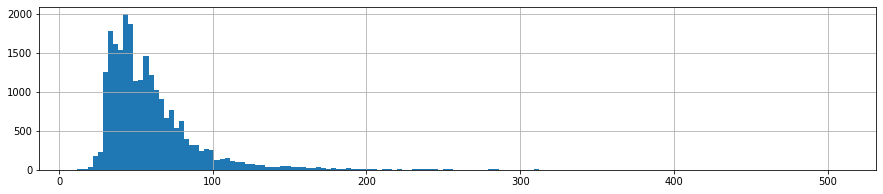

```python
# check
data.total_area.hist(bins = 150, figsize = (15,3));
```

Все квартиры более 250-ти квадратных метров можно считать редкостями.

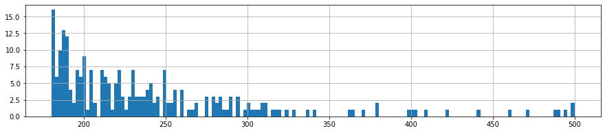

```python
# check
data.total_area.hist(bins = 150, figsize = (15,3), range = (180,500));
```

Удалим строки в которых значение столбце 'total_area' более 250 м².

```python
data = data[~(data['total_area'] > 250)]
```

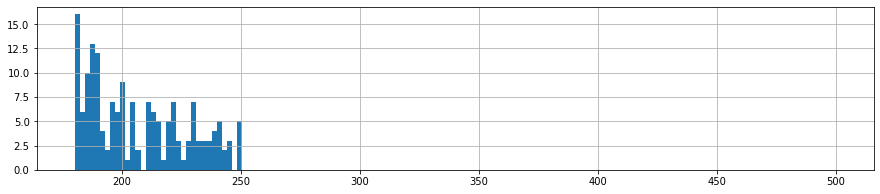

```python
# check
data.total_area.hist(bins = 150, figsize = (15,3), range = (180,500));
```

```python
# check

# Значения параметров объектов недвижимости на разных квантилях

(
    data[['rooms', 'total_area', 'ceiling_height', 'days_exposition', 'last_price', 'living_area',
        'kitchen_area', 'floor',   'floors_total']]
    .quantile([0.01, .5, .90, .9976])
    .style.format("{:,.2f}")
)
```

|  | rooms | total_area | ceiling_height | days_exposition | last_price | living_area | kitchen_area | floor | floors_total |
| --- | --- | --- | --- | --- | --- | --- | --- | --- | --- |
| 0.01 | 1.00 | 25.30 | 2.50 | 4.00 | 1,000,000.00 | 13.00 | 3.89 | 1.00 | 2.00 |
| 0.5 | 2.00 | 52.00 | 2.64 | 95.00 | 4,600,000.00 | 30.20 | 9.00 | 4.00 | 9.00 |
| 0.9 | 3.00 | 91.79 | 3.00 | 457.00 | 10,500,000.00 | 55.00 | 15.70 | 13.00 | 22.00 |
| 0.9976 | 6.00 | 215.17 | 4.00 | 1,310.05 | 58,403,534.40 | 140.84 | 45.95 | 25.00 | 27.00 |

Изучим данные столбца 'ceiling_height'. Помним, что минимальное значение в этом столбце - 1 м, максимальное - 10 м.

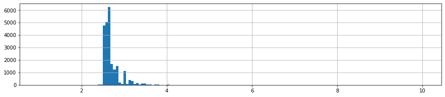

```python
# check
data.ceiling_height.hist(bins = 150, figsize = (15,3));
```

На гистограмме значения меньше 2 метров и более 4.5 сравнялись с 0, значит таких значений очень мало. Удалим строки в столбце 'ceiling_height' со значениями меньше или равное 2, и более или равное 4.5.

```python
data = data[~(data['ceiling_height'] <= 2) & ~(data['ceiling_height'] >= 4.5)]
```

```python
# check
(
    data[['ceiling_height']]
    .apply (['count', 'min', 'max'])
    .style.format("{:,.2f}")
)
```

|  | ceiling_height |
| --- | --- |
| count | 23,365.00 |
| min | 2.20 |
| max | 4.45 |

Изучим данные столбца 'days_exposition'.

```python
(
    data[['days_exposition']]
    .apply (['count', 'min', 'max'])
    .style.format("{:,.2f}")
)
```

|  | days_exposition |
| --- | --- |
| count | 20,243.00 |
| min | 1.00 |
| max | 1,580.00 |

Минимальное количество дней - 1. Исследуем количество таких значений.

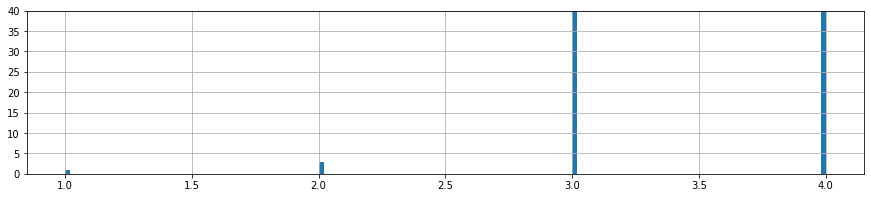

```python
# check
data.days_exposition.hist(bins = 150, figsize = (15,3), range=(1, 4));
plt.ylim(0,40);
```

Значение 1 и 2 - для нашей выборки являются редкими и аномально-маленькими.

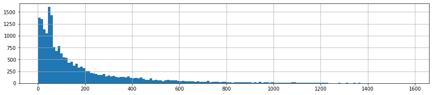

```python
# check
data.days_exposition.hist(bins = 150, figsize = (15,3));
```

Значения, которые привысили 1200 дней практически слились с 0, и являются редкими.

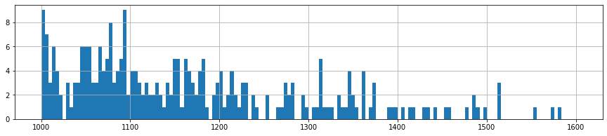

```python
# check
data.days_exposition.hist(bins = 150, figsize = (15,3), range=(1000, 1600));
```

```python
# удалим редкие значения в столбце 'days_exposition'
data = data[~(data['days_exposition'] >= 1200) & ~(data['days_exposition'] <= 2)]
```

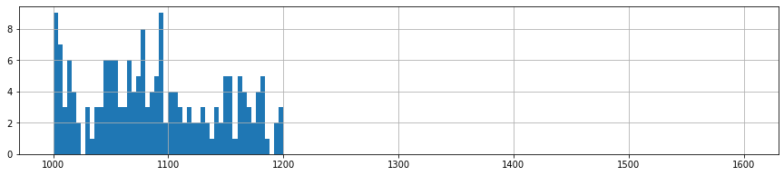

```python
# check
data.days_exposition.hist(bins = 150, figsize = (15,3), range=(1000, 1600));
```

```python
# check
(
    data[['days_exposition']]
    .apply (['count', 'min', 'max'])
    .style.format("{:,.2f}")
)
```

|  | days_exposition |
| --- | --- |
| count | 20,150.00 |
| min | 3.00 |
| max | 1,199.00 |

Исследуем значения в столбце 'last_price'.

```python
(
    data[['last_price']]
    .apply (['count', 'min', 'max'])
    .style.format("{:,.2f}")
)
```

|  | last_price |
| --- | --- |
| count | 23,272.00 |
| min | 12,190.00 |
| max | 330,000,000.00 |

Обратим внимание на аномально-маленькое минимальное значение - 12,190.00 рублей.

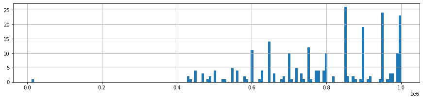

```python
# check
data.last_price.hist(bins = 150, figsize = (15,3), range=(12000, 1000000));
```

Значения до 600,000.00 рублей являются редкими.

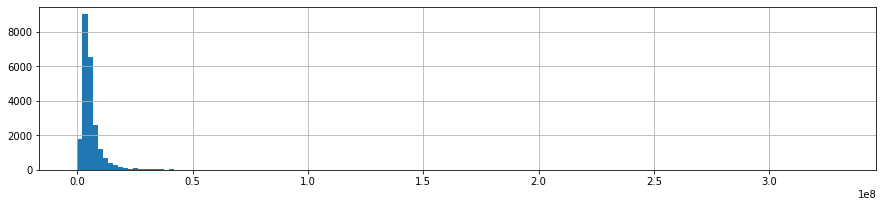

```python
# check
data.last_price.hist(bins = 150, figsize = (15,3));
```

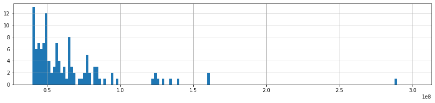

```python
# исследуем 50,000,000.00 рублей слились с нулевым значением, рассмотрим их ближе:
data.last_price.hist(bins = 150, figsize = (15,3), range=(40000000, 300000000));
```

Значения больше 100,000,000 - являются редкими.

```python
# удалим редкие значения в столбце 'last_price'
data = data[~(data['last_price'] >= 100000000) & ~(data['last_price'] <= 600000)]
```

```python
# check
(
    data[['last_price']]
    .apply (['count', 'min', 'max'])
    .style.format("{:,.2f}")
)
```

|  | last_price |
| --- | --- |
| count | 23,218.00 |
| min | 620,000.00 |
| max | 98,000,000.00 |

Исследуем данные в столбце 'living_area'.

```python
# check
(
    data[['living_area']]
    .apply (['count', 'min', 'max'])
    .style.format("{:,.2f}")
)
```

|  | living_area |
| --- | --- |
| count | 23,218.00 |
| min | 2.00 |
| max | 200.00 |

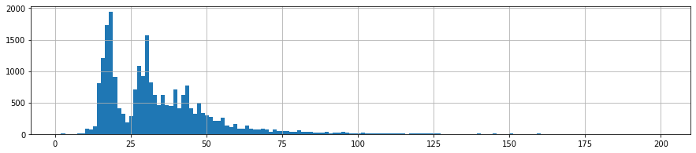

```python
# check
data.living_area.hist(bins = 150, figsize = (15,3));
```

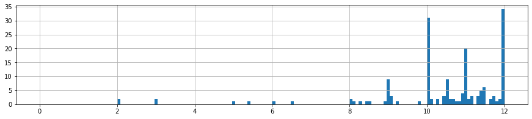

```python
# исследуем значения до 12 м²:
data.living_area.hist(bins = 150, figsize = (15,3), range=(0, 12));
```

Значения менее 10 квадратных метров являются редкими и аномально маленькими.

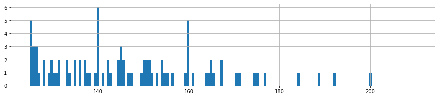

```python
# исследуем значения более 125 м²:
data.living_area.hist(bins = 150, figsize = (15,3), range=(125, 210));
```

Жилая площадь более 160 м² для нашей выборки является редкостью.

```python
# удалим редкие значения в столбце 'last_price'
data = data[~(data['living_area'] > 160) & ~(data['living_area'] <= 10)]
```

```python
# check
(
    data[['living_area']]
    .apply (['count', 'min', 'max'])
    .style.format("{:,.2f}")
)
```

|  | living_area |
| --- | --- |
| count | 23,141.00 |
| min | 10.08 |
| max | 160.00 |

Обработаем аномальные значения в столбце 'kitchen_area'.

```python
# check
(
    data[['kitchen_area']]
    .apply (['count', 'min', 'max'])
    .style.format("{:,.2f}")
)
```

|  | kitchen_area |
| --- | --- |
| count | 23,141.00 |
| min | 0.04 |
| max | 107.00 |

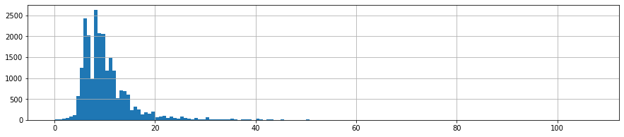

```python
data.kitchen_area.hist(bins = 150, figsize = (15,3));
```

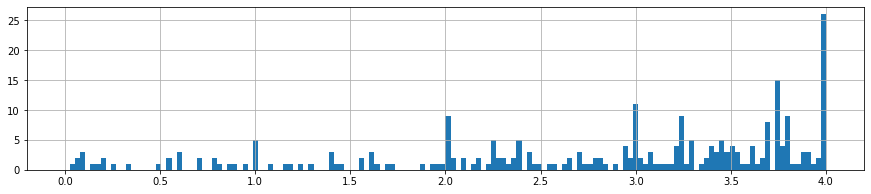

```python
# рассмотрим значения площади кухни до 4 м²:
data.kitchen_area.hist(bins = 150, figsize = (15,3), range=(0, 4));
```

Площадь кухни до 4 м² - является редким и аномально-маленьким значением.

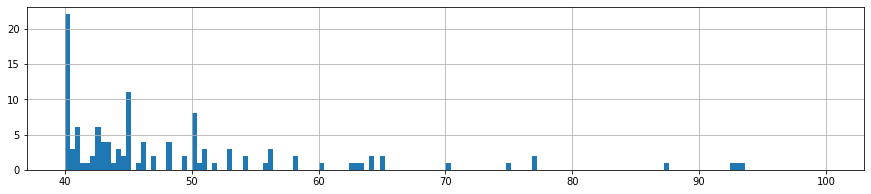

```python
# рассмотрим значения площади кухни более 40 м²:
data.kitchen_area.hist(bins = 150, figsize = (15,3), range=(40, 100));
```

Значения более 50 м² - являются редкими.

```python
# удалим редкие значения в столбце 'kitchen_area'
data = data[~(data['kitchen_area'] > 50) & ~(data['kitchen_area'] < 4)]
```

```python
# check
(
    data[['kitchen_area']]
    .apply (['count', 'min', 'max'])
    .style.format("{:,.2f}")
)
```

|  | kitchen_area |
| --- | --- |
| count | 22,871.00 |
| min | 4.00 |
| max | 50.00 |

После обработки аномальных значений для столбцов 'kitchen_area' и 'living_area', проверим условие - (total_area*0.9 <= (living_area + kitchen_area))

```python
data.query('total_area*0.9 <= (living_area + kitchen_area)')
```

|  | total_images | last_price | total_area | first_day_exposition | rooms | ceiling_height | floors_total | living_area | floor | is_apartment | ... | kitchen_area | balcony | locality_name | airports_nearest | cityCenters_nearest | parks_around3000 | parks_nearest | ponds_around3000 | ponds_nearest | days_exposition |
| --- | --- | --- | --- | --- | --- | --- | --- | --- | --- | --- | --- | --- | --- | --- | --- | --- | --- | --- | --- | --- | --- |
| 41 | 16 | 7900000.0 | 74.0 | 2016-05-04 | 3 | 2.65 | 14 | 59.0 | 8 | False | ... | 12.0 | 5 | Санкт-Петербург | 37715.0 | 12612.0 | 1.0 | 725.0 | 1.0 | 759.0 | 179.0 |
| 171 | 6 | 3800000.0 | 49.0 | 2019-02-22 | 2 | 2.50 | 9 | 38.0 | 8 | False | ... | 10.0 | 1 | Шушары | 18471.0 | 24272.0 | 0.0 | 460.0 | 0.0 | 584.5 | 11.0 |
| 184 | 7 | 2600000.0 | 30.2 | 2018-02-14 | 1 | 2.65 | 9 | 26.1 | 5 | False | ... | 6.2 | 0 | Санкт-Петербург | 13952.0 | 15031.0 | 0.0 | 460.0 | 1.0 | 824.0 | 12.0 |
| 220 | 8 | 3890000.0 | 37.0 | 2018-07-09 | 1 | 2.50 | 25 | 28.0 | 6 | False | ... | 9.0 | 0 | Санкт-Петербург | 25408.0 | 16166.0 | 0.0 | 460.0 | 0.0 | 504.0 | 28.0 |
| 319 | 19 | 4850000.0 | 59.7 | 2015-03-19 | 3 | 2.50 | 5 | 47.4 | 4 | False | ... | 6.4 | 1 | Санкт-Петербург | 43095.0 | 15599.0 | 0.0 | 460.0 | 0.0 | 504.0 | 974.0 |
| ... | ... | ... | ... | ... | ... | ... | ... | ... | ... | ... | ... | ... | ... | ... | ... | ... | ... | ... | ... | ... | ... |
| 23216 | 15 | 10150000.0 | 114.0 | 2015-01-21 | 4 | 2.80 | 5 | 90.2 | 4 | False | ... | 16.0 | 0 | Санкт-Петербург | 26259.0 | 4961.0 | 0.0 | 460.0 | 2.0 | 838.0 | 1052.0 |
| 23297 | 10 | 1850000.0 | 48.2 | 2019-03-13 | 2 | 2.60 | 5 | 42.2 | 2 | False | ... | 6.0 | 1 | Высоцк | 26763.0 | NaN | 0.0 | 460.0 | 0.0 | 504.0 | 45.0 |
| 23328 | 12 | 4299000.0 | 54.0 | 2016-11-25 | 2 | 2.60 | 14 | 40.0 | 8 | False | ... | 10.0 | 0 | Колпино | 25612.0 | 31399.0 | 0.0 | 393.0 | 0.0 | 509.0 | 343.0 |
| 23521 | 13 | 8500000.0 | 65.0 | 2018-11-01 | 2 | 2.60 | 4 | 44.0 | 2 | False | ... | 15.3 | 0 | Санкт-Петербург | 22276.0 | 3996.0 | 1.0 | 627.0 | 0.0 | 504.0 | NaN |
| 23680 | 14 | 5000000.0 | 59.0 | 2019-04-04 | 3 | 2.50 | 5 | 52.0 | 1 | False | ... | 7.0 | 0 | Санкт-Петербург | 26835.0 | 11878.0 | 0.0 | 460.0 | 0.0 | 504.0 | NaN |

456 rows × 22 columns

Исследуем значения в столбцах 'floor' и 'floors_total'.

```python
# check
(
    data[['floor', 'floors_total']]
    .apply (['count', 'min', 'max'])
    .style.format("{:,.2f}")
)
```

|  | floor | floors_total |
| --- | --- | --- |
| count | 22,871.00 | 22,871.00 |
| min | 1.00 | 1.00 |
| max | 33.00 | 60.00 |

Значения в столбце 'floor' не выглядят аномальными, и не помешают дальнейшему анализу данных. Оставим их без изменений.

Значения близкие к максимальному в столбце 'floors_total' рассмотрим по-ближе.

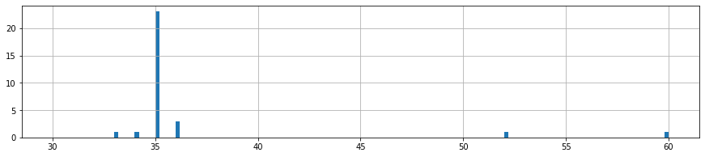

```python
data.floors_total.hist(bins = 150, figsize = (15,3), range=(30, 60));
```

Значения более 40 этажей являются редкими.

```python
# удалим редкие значения в столбце 'kitchen_area'
data = data[~(data['floors_total'] >= 40)]
```

```python
# check
(
    data[['floor', 'floors_total']]
    .apply (['count', 'min', 'max'])
    .style.format("{:,.2f}")
)
```

|  | floor | floors_total |
| --- | --- | --- |
| count | 22,869.00 | 22,869.00 |
| min | 1.00 | 1.00 |
| max | 33.00 | 36.00 |

```python
# check
data.info()
```

```
<class 'pandas.core.frame.DataFrame'>
Int64Index: 22869 entries, 0 to 23698
Data columns (total 22 columns):
 #   Column                Non-Null Count  Dtype
---  ------                --------------  -----
 0   total_images          22869 non-null  int64
 1   last_price            22869 non-null  float64
 2   total_area            22869 non-null  float64
 3   first_day_exposition  22869 non-null  datetime64[ns]
 4   rooms                 22869 non-null  int64
 5   ceiling_height        22869 non-null  float64
 6   floors_total          22869 non-null  int64
 7   living_area           22869 non-null  float64
 8   floor                 22869 non-null  int64
 9   is_apartment          22869 non-null  bool
 10  studio                22869 non-null  bool
 11  open_plan             22869 non-null  bool
 12  kitchen_area          22869 non-null  float64
 13  balcony               22869 non-null  int64
 14  locality_name         22869 non-null  object
 15  airports_nearest      22869 non-null  float64
 16  cityCenters_nearest   17551 non-null  float64
 17  parks_around3000      22869 non-null  float64
 18  parks_nearest         22869 non-null  float64
 19  ponds_around3000      22869 non-null  float64
 20  ponds_nearest         22869 non-null  float64
 21  days_exposition       19789 non-null  float64
dtypes: bool(3), datetime64[ns](1), float64(12), int64(5), object(1)
memory usage: 3.6+ MB
```

```python
# check
(
    data[['rooms', 'total_area', 'ceiling_height', 'days_exposition', 'last_price', 'living_area',  'kitchen_area',
          'floor', 'floors_total']]
    .apply (['count', 'min', 'max'])
    .style.format("{:,.2f}")
)
```

|  | rooms | total_area | ceiling_height | days_exposition | last_price | living_area | kitchen_area | floor | floors_total |
| --- | --- | --- | --- | --- | --- | --- | --- | --- | --- |
| count | 22,869.00 | 22,869.00 | 22,869.00 | 19,789.00 | 22,869.00 | 22,869.00 | 22,869.00 | 22,869.00 | 22,869.00 |
| min | 0.00 | 20.00 | 2.20 | 3.00 | 620,000.00 | 10.08 | 4.00 | 1.00 | 1.00 |
| max | 6.00 | 250.00 | 4.40 | 1,199.00 | 98,000,000.00 | 160.00 | 50.00 | 33.00 | 36.00 |

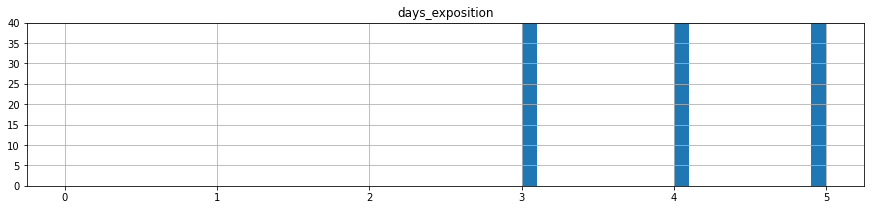

```python
# check
data.hist(column = 'days_exposition', bins = 50, figsize = (15,3), range = (0,5))
plt.ylim(0,40);
```

### Добавление в таблицу новых столбцов

Добавим в таблицу столбец `price_square_meter` - цена одного квадратного метра. Для этого разделим столбец `last_price` - цена на момент снятия с публикации, на столбец `total_area` - общая площадь квартиры в квадратных метрах.

```python
data['price_square_meter'] = data['last_price'] / data['total_area']
data['price_square_meter'].head(10)
```

```
0    120370.370370
1     82920.792079
2     92785.714286
3    408176.100629
4    100000.000000
5     95065.789474
6     99195.710456
7    110544.692737
8     87454.764777
9     88524.590164
Name: price_square_meter, dtype: float64
```

Добавим столбец `week_day` - день недели публикации объявления (0 — понедельник, 1 — вторник и так далее).

```python
data['week_day'] = data['first_day_exposition'].dt.weekday
data['week_day'].head(10)
```

```
0    3
1    1
2    3
3    4
4    1
5    0
6    3
7    3
8    2
9    6
Name: week_day, dtype: int64
```

Добавим столбец `month_publication` - месяц публикации объявления.

```python
data['month_publication'] = data['first_day_exposition'].dt.month
data.head(10)
```

|  | total_images | last_price | total_area | first_day_exposition | rooms | ceiling_height | floors_total | living_area | floor | is_apartment | ... | airports_nearest | cityCenters_nearest | parks_around3000 | parks_nearest | ponds_around3000 | ponds_nearest | days_exposition | price_square_meter | week_day | month_publication |
| --- | --- | --- | --- | --- | --- | --- | --- | --- | --- | --- | --- | --- | --- | --- | --- | --- | --- | --- | --- | --- | --- |
| 0 | 20 | 13000000.0 | 108.00 | 2019-03-07 | 3 | 2.70 | 16 | 51.00 | 8 | False | ... | 18863.0 | 16028.0 | 1.0 | 482.0 | 2.0 | 755.0 | NaN | 120370.370370 | 3 | 3 |
| 1 | 7 | 3350000.0 | 40.40 | 2018-12-04 | 1 | 2.64 | 11 | 18.60 | 1 | False | ... | 12817.0 | 18603.0 | 0.0 | 460.0 | 0.0 | 584.5 | 81.0 | 82920.792079 | 1 | 12 |
| 2 | 10 | 5196000.0 | 56.00 | 2015-08-20 | 2 | 2.60 | 5 | 34.30 | 4 | False | ... | 21741.0 | 13933.0 | 1.0 | 90.0 | 2.0 | 574.0 | 558.0 | 92785.714286 | 3 | 8 |
| 3 | 0 | 64900000.0 | 159.00 | 2015-07-24 | 3 | 2.65 | 14 | 111.30 | 9 | False | ... | 28098.0 | 6800.0 | 2.0 | 84.0 | 3.0 | 234.0 | 424.0 | 408176.100629 | 4 | 7 |
| 4 | 2 | 10000000.0 | 100.00 | 2018-06-19 | 2 | 3.03 | 14 | 32.00 | 13 | False | ... | 31856.0 | 8098.0 | 2.0 | 112.0 | 1.0 | 48.0 | 121.0 | 100000.000000 | 1 | 6 |
| 5 | 10 | 2890000.0 | 30.40 | 2018-09-10 | 1 | 2.64 | 12 | 14.40 | 5 | False | ... | 26763.0 | NaN | 0.0 | 460.0 | 0.0 | 504.0 | 55.0 | 95065.789474 | 0 | 9 |
| 6 | 6 | 3700000.0 | 37.30 | 2017-11-02 | 1 | 2.64 | 26 | 10.60 | 6 | False | ... | 52996.0 | 19143.0 | 0.0 | 733.0 | 0.0 | 593.0 | 155.0 | 99195.710456 | 3 | 11 |
| 7 | 5 | 7915000.0 | 71.60 | 2019-04-18 | 2 | 2.60 | 24 | 41.96 | 22 | False | ... | 23982.0 | 11634.0 | 0.0 | 460.0 | 0.0 | 504.0 | NaN | 110544.692737 | 3 | 4 |
| 8 | 20 | 2900000.0 | 33.16 | 2018-05-23 | 1 | 2.64 | 27 | 15.43 | 26 | False | ... | 26763.0 | NaN | 0.0 | 460.0 | 0.0 | 504.0 | 189.0 | 87454.764777 | 2 | 5 |
| 9 | 18 | 5400000.0 | 61.00 | 2017-02-26 | 3 | 2.50 | 9 | 43.60 | 7 | False | ... | 50898.0 | 15008.0 | 0.0 | 460.0 | 0.0 | 504.0 | 289.0 | 88524.590164 | 6 | 2 |

10 rows × 25 columns

Добавим столбец `year_publication` - год публикации объявления.

```python
data['year_publication'] = data['first_day_exposition'].dt.year
data.head(10)
```

|  | total_images | last_price | total_area | first_day_exposition | rooms | ceiling_height | floors_total | living_area | floor | is_apartment | ... | cityCenters_nearest | parks_around3000 | parks_nearest | ponds_around3000 | ponds_nearest | days_exposition | price_square_meter | week_day | month_publication | year_publication |
| --- | --- | --- | --- | --- | --- | --- | --- | --- | --- | --- | --- | --- | --- | --- | --- | --- | --- | --- | --- | --- | --- |
| 0 | 20 | 13000000.0 | 108.00 | 2019-03-07 | 3 | 2.70 | 16 | 51.00 | 8 | False | ... | 16028.0 | 1.0 | 482.0 | 2.0 | 755.0 | NaN | 120370.370370 | 3 | 3 | 2019 |
| 1 | 7 | 3350000.0 | 40.40 | 2018-12-04 | 1 | 2.64 | 11 | 18.60 | 1 | False | ... | 18603.0 | 0.0 | 460.0 | 0.0 | 584.5 | 81.0 | 82920.792079 | 1 | 12 | 2018 |
| 2 | 10 | 5196000.0 | 56.00 | 2015-08-20 | 2 | 2.60 | 5 | 34.30 | 4 | False | ... | 13933.0 | 1.0 | 90.0 | 2.0 | 574.0 | 558.0 | 92785.714286 | 3 | 8 | 2015 |
| 3 | 0 | 64900000.0 | 159.00 | 2015-07-24 | 3 | 2.65 | 14 | 111.30 | 9 | False | ... | 6800.0 | 2.0 | 84.0 | 3.0 | 234.0 | 424.0 | 408176.100629 | 4 | 7 | 2015 |
| 4 | 2 | 10000000.0 | 100.00 | 2018-06-19 | 2 | 3.03 | 14 | 32.00 | 13 | False | ... | 8098.0 | 2.0 | 112.0 | 1.0 | 48.0 | 121.0 | 100000.000000 | 1 | 6 | 2018 |
| 5 | 10 | 2890000.0 | 30.40 | 2018-09-10 | 1 | 2.64 | 12 | 14.40 | 5 | False | ... | NaN | 0.0 | 460.0 | 0.0 | 504.0 | 55.0 | 95065.789474 | 0 | 9 | 2018 |
| 6 | 6 | 3700000.0 | 37.30 | 2017-11-02 | 1 | 2.64 | 26 | 10.60 | 6 | False | ... | 19143.0 | 0.0 | 733.0 | 0.0 | 593.0 | 155.0 | 99195.710456 | 3 | 11 | 2017 |
| 7 | 5 | 7915000.0 | 71.60 | 2019-04-18 | 2 | 2.60 | 24 | 41.96 | 22 | False | ... | 11634.0 | 0.0 | 460.0 | 0.0 | 504.0 | NaN | 110544.692737 | 3 | 4 | 2019 |
| 8 | 20 | 2900000.0 | 33.16 | 2018-05-23 | 1 | 2.64 | 27 | 15.43 | 26 | False | ... | NaN | 0.0 | 460.0 | 0.0 | 504.0 | 189.0 | 87454.764777 | 2 | 5 | 2018 |
| 9 | 18 | 5400000.0 | 61.00 | 2017-02-26 | 3 | 2.50 | 9 | 43.60 | 7 | False | ... | 15008.0 | 0.0 | 460.0 | 0.0 | 504.0 | 289.0 | 88524.590164 | 6 | 2 | 2017 |

10 rows × 26 columns

Добавим столбец `floor_type` - тип этажа квартиры (значения — «первый», «последний», «другой»). Для этого напишем функцию - "apartment_floor".

```python
def apartment_floor(row):
    if row['floor'] == 1:
        return 'первый'
    elif row['floor'] == row['floors_total']:
        return 'последний'
    else:
        return 'другой'
```

```python
data['floor_type'] = data.apply(apartment_floor, axis=1)
data.head(20)
```

|  | total_images | last_price | total_area | first_day_exposition | rooms | ceiling_height | floors_total | living_area | floor | is_apartment | ... | parks_around3000 | parks_nearest | ponds_around3000 | ponds_nearest | days_exposition | price_square_meter | week_day | month_publication | year_publication | floor_type |
| --- | --- | --- | --- | --- | --- | --- | --- | --- | --- | --- | --- | --- | --- | --- | --- | --- | --- | --- | --- | --- | --- |
| 0 | 20 | 13000000.0 | 108.00 | 2019-03-07 | 3 | 2.70 | 16 | 51.00 | 8 | False | ... | 1.0 | 482.0 | 2.0 | 755.0 | NaN | 120370.370370 | 3 | 3 | 2019 | другой |
| 1 | 7 | 3350000.0 | 40.40 | 2018-12-04 | 1 | 2.64 | 11 | 18.60 | 1 | False | ... | 0.0 | 460.0 | 0.0 | 584.5 | 81.0 | 82920.792079 | 1 | 12 | 2018 | первый |
| 2 | 10 | 5196000.0 | 56.00 | 2015-08-20 | 2 | 2.60 | 5 | 34.30 | 4 | False | ... | 1.0 | 90.0 | 2.0 | 574.0 | 558.0 | 92785.714286 | 3 | 8 | 2015 | другой |
| 3 | 0 | 64900000.0 | 159.00 | 2015-07-24 | 3 | 2.65 | 14 | 111.30 | 9 | False | ... | 2.0 | 84.0 | 3.0 | 234.0 | 424.0 | 408176.100629 | 4 | 7 | 2015 | другой |
| 4 | 2 | 10000000.0 | 100.00 | 2018-06-19 | 2 | 3.03 | 14 | 32.00 | 13 | False | ... | 2.0 | 112.0 | 1.0 | 48.0 | 121.0 | 100000.000000 | 1 | 6 | 2018 | другой |
| 5 | 10 | 2890000.0 | 30.40 | 2018-09-10 | 1 | 2.64 | 12 | 14.40 | 5 | False | ... | 0.0 | 460.0 | 0.0 | 504.0 | 55.0 | 95065.789474 | 0 | 9 | 2018 | другой |
| 6 | 6 | 3700000.0 | 37.30 | 2017-11-02 | 1 | 2.64 | 26 | 10.60 | 6 | False | ... | 0.0 | 733.0 | 0.0 | 593.0 | 155.0 | 99195.710456 | 3 | 11 | 2017 | другой |
| 7 | 5 | 7915000.0 | 71.60 | 2019-04-18 | 2 | 2.60 | 24 | 41.96 | 22 | False | ... | 0.0 | 460.0 | 0.0 | 504.0 | NaN | 110544.692737 | 3 | 4 | 2019 | другой |
| 8 | 20 | 2900000.0 | 33.16 | 2018-05-23 | 1 | 2.64 | 27 | 15.43 | 26 | False | ... | 0.0 | 460.0 | 0.0 | 504.0 | 189.0 | 87454.764777 | 2 | 5 | 2018 | другой |
| 9 | 18 | 5400000.0 | 61.00 | 2017-02-26 | 3 | 2.50 | 9 | 43.60 | 7 | False | ... | 0.0 | 460.0 | 0.0 | 504.0 | 289.0 | 88524.590164 | 6 | 2 | 2017 | другой |
| 10 | 5 | 5050000.0 | 39.60 | 2017-11-16 | 1 | 2.67 | 12 | 20.30 | 3 | False | ... | 1.0 | 310.0 | 2.0 | 553.0 | 137.0 | 127525.252525 | 3 | 11 | 2017 | другой |
| 11 | 9 | 3300000.0 | 44.00 | 2018-08-27 | 2 | 2.60 | 5 | 31.00 | 4 | False | ... | 0.0 | 407.0 | 0.0 | 553.0 | 7.0 | 75000.000000 | 0 | 8 | 2018 | другой |
| 12 | 10 | 3890000.0 | 54.00 | 2016-06-30 | 2 | 2.60 | 5 | 30.00 | 5 | False | ... | 0.0 | 460.0 | 0.0 | 504.0 | 90.0 | 72037.037037 | 3 | 6 | 2016 | последний |
| 13 | 20 | 3550000.0 | 42.80 | 2017-07-01 | 2 | 2.56 | 5 | 27.00 | 5 | False | ... | 1.0 | 294.0 | 3.0 | 298.0 | 366.0 | 82943.925234 | 5 | 7 | 2017 | последний |
| 14 | 1 | 4400000.0 | 36.00 | 2016-06-23 | 1 | 2.64 | 6 | 17.00 | 1 | False | ... | 0.0 | 399.5 | 1.0 | 96.0 | 203.0 | 122222.222222 | 3 | 6 | 2016 | первый |
| 15 | 16 | 4650000.0 | 39.00 | 2017-11-18 | 1 | 2.64 | 14 | 20.50 | 5 | False | ... | 1.0 | 590.0 | 1.0 | 296.0 | 19.0 | 119230.769231 | 5 | 11 | 2017 | другой |
| 16 | 11 | 6700000.0 | 82.00 | 2017-11-23 | 3 | 3.05 | 5 | 55.60 | 1 | False | ... | 3.0 | 420.0 | 0.0 | 504.0 | 397.0 | 81707.317073 | 3 | 11 | 2017 | первый |
| 17 | 6 | 4180000.0 | 36.00 | 2016-09-09 | 1 | 2.64 | 17 | 16.50 | 7 | False | ... | 0.0 | 460.0 | 1.0 | 859.0 | 571.0 | 116111.111111 | 4 | 9 | 2016 | другой |
| 18 | 8 | 3250000.0 | 31.00 | 2017-01-27 | 1 | 2.50 | 5 | 19.40 | 2 | False | ... | 1.0 | 759.0 | 0.0 | 504.0 | 168.0 | 104838.709677 | 4 | 1 | 2017 | другой |
| 19 | 16 | 14200000.0 | 121.00 | 2019-01-09 | 3 | 2.75 | 16 | 76.00 | 8 | False | ... | 0.0 | 460.0 | 0.0 | 504.0 | 97.0 | 117355.371901 | 2 | 1 | 2019 | другой |

20 rows × 27 columns

Добавим столбец 'distance_to_center' - расстояние до центра города в километрах. Для этого столбец `cityCenters_nearest` разделим на 1000 и округлим до целых чисел.

```python
data['distance_to_center'] = data['cityCenters_nearest'] / 1000
data['distance_to_center'] = data['distance_to_center'].round()
data.head()
```

|  | total_images | last_price | total_area | first_day_exposition | rooms | ceiling_height | floors_total | living_area | floor | is_apartment | ... | parks_nearest | ponds_around3000 | ponds_nearest | days_exposition | price_square_meter | week_day | month_publication | year_publication | floor_type | distance_to_center |
| --- | --- | --- | --- | --- | --- | --- | --- | --- | --- | --- | --- | --- | --- | --- | --- | --- | --- | --- | --- | --- | --- |
| 0 | 20 | 13000000.0 | 108.0 | 2019-03-07 | 3 | 2.70 | 16 | 51.0 | 8 | False | ... | 482.0 | 2.0 | 755.0 | NaN | 120370.370370 | 3 | 3 | 2019 | другой | 16.0 |
| 1 | 7 | 3350000.0 | 40.4 | 2018-12-04 | 1 | 2.64 | 11 | 18.6 | 1 | False | ... | 460.0 | 0.0 | 584.5 | 81.0 | 82920.792079 | 1 | 12 | 2018 | первый | 19.0 |
| 2 | 10 | 5196000.0 | 56.0 | 2015-08-20 | 2 | 2.60 | 5 | 34.3 | 4 | False | ... | 90.0 | 2.0 | 574.0 | 558.0 | 92785.714286 | 3 | 8 | 2015 | другой | 14.0 |
| 3 | 0 | 64900000.0 | 159.0 | 2015-07-24 | 3 | 2.65 | 14 | 111.3 | 9 | False | ... | 84.0 | 3.0 | 234.0 | 424.0 | 408176.100629 | 4 | 7 | 2015 | другой | 7.0 |
| 4 | 2 | 10000000.0 | 100.0 | 2018-06-19 | 2 | 3.03 | 14 | 32.0 | 13 | False | ... | 112.0 | 1.0 | 48.0 | 121.0 | 100000.000000 | 1 | 6 | 2018 | другой | 8.0 |

5 rows × 28 columns

### Исследовательский анализ данных

#### Исследование данных по параметрам

Изучим и опишем следующие параметры объектов:

1. общая площадь;
2. жилая площадь;
3. площадь кухни;
4. цена объекта;
5. количество комнат;
6. высота потолков;
7. этаж квартиры;
8. тип этажа квартиры («первый», «последний», «другой»);
9. общее количество этажей в доме;
10. расстояние до центра города в метрах;
11. расстояние до ближайшего аэропорта;
12. расстояние до ближайшего парка;
13. день публикации объявления;
14. месяц публикации объявления.

##### Общая площадь

Построим гистограмму для столбца `total_area` - общая площадь в квадратных метрах.

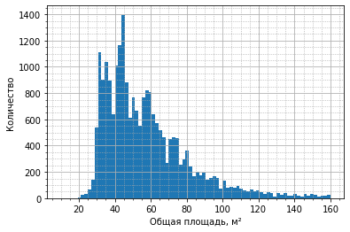

```python
data['total_area'].hist(bins=80, figsize=(6, 4), range=(10, 160));
plt.minorticks_on()
plt.grid(which='minor', color='#aaa', ls=':')
plt.xlabel('Общая площадь, м²');
plt.ylabel('Количество');
```

##### Жилая площадь

Построим гистограмму для столбца `living_area` - жилая площадь в квадратных метрах.

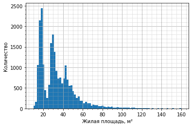

```python
data['living_area'].hist(bins=80, figsize=(6, 4), range=(10, 160));
plt.minorticks_on()
plt.grid(which='minor', color='#aaa', ls=':')
plt.xlabel('Жилая площадь, м²');
plt.ylabel('Количество');
```

На гистограмме наблюдается три пика. Самый высокий пик - это количество квартир с жилой площадью 15-20 м², таких предложений больше 2400. Второй пик - квартиры с жилой площадью около 30 м² - 1800 предложений. Третий пик - квартиры с площадью 40-45 м². Количество квартир с жилой площадью от 100 м² и выше - постепенно стремится к 1.

##### Площадь кухни

Построим гистограмму для столбца `kitchen_area` — площадь кухни в квадратных метрах.

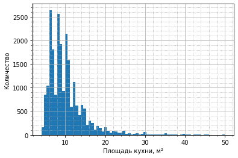

```python
data['kitchen_area'].hist(bins=70, figsize=(6, 4), range=(4, 50));
plt.minorticks_on()
plt.grid(which='minor', color='#aaa', ls=':')
plt.xlabel('Площадь кухни, м²');
plt.ylabel('Количество');
```

На гистограмме наблюдаем четыре пика. Самый высокий пик - количество квартир с площадью кухни 6 м², таких предложений более 2600. Второй по высоте пик - квартиры с площадью кухни около 8 м² - более 2500 предложений. Третий пик - кухни с площадью около 10 м² - более 2100 предложений. Четвертый пик - кухни с площадью 12 м², около 1100 объявлений. Количество кухонь с площадью от 20 м² и выше, начинается от 150 предложений и постепенно стремится к 1.

##### Цена объекта

Построим гистограмму цены объектов.

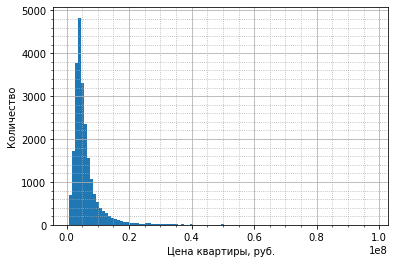

```python
data['last_price'].hist(bins=100, figsize=(6, 4), range=(620000, 98000000));
plt.minorticks_on()
plt.grid(which='minor', color='#aaa', ls=':')
plt.xlabel('Цена квартиры, руб.');
plt.ylabel('Количество');
```

Пик на гистограмме характеризует самое большое количество квартир со стоимостью квартир около 3-4 млн рублей - более 4800 предложений. Далее наблюдаем постепенное падение предложений и ростом цены до 20 млн рублей. Количество предложений со стоимостью квартир от 20 млн и выше постепенно стремится к 1.

##### Количество комнат

Посторим гистограмму по количеству комнат.

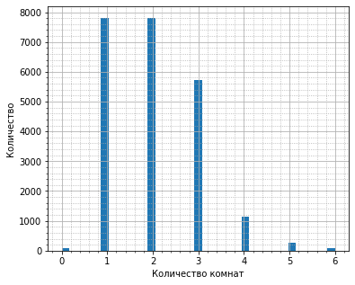

```python
data['rooms'].hist(bins=35, figsize=(6, 5), range=(0, 6));
plt.minorticks_on()
plt.grid(which='minor', color='#aaa', ls=':')
plt.xlabel('Количество комнат');
plt.ylabel('Количество');
```

Самое большое количество однокомнатных и двухкомнатных квартир - около 7800. Количество трехкомнытных квартир - менее 5800. Количество четырехкомнатных квартир - более 1000.

##### Высота потолков

Гистограмма высоты потолков.

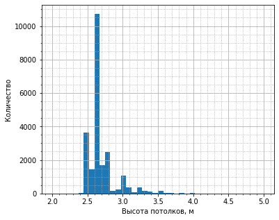

```python
data['ceiling_height'].hist(bins=40, figsize=(6, 5), range=(2, 5));
plt.minorticks_on()
plt.grid(which='minor', color='#aaa', ls=':')
plt.xlabel('Высота потолков, м');
plt.ylabel('Количество');
```

##### Этаж квартиры

Построим гистограмму по этажу квартиры.

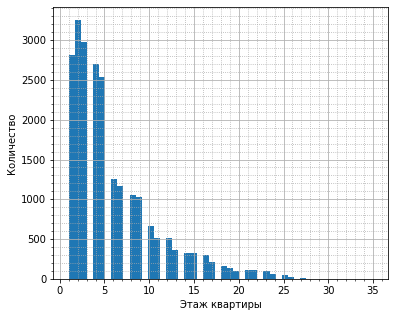

```python
data['floor'].hist(bins=50, figsize=(6, 5), range=(1, 35));
plt.minorticks_on()
plt.grid(which='minor', color='#aaa', ls=':')
plt.xlabel('Этаж квартиры');
plt.ylabel('Количество');
```

Самое большое количество квартир находятся на втором этаже - более 3200. Немного меньше квартир на первом и третьем этаже - около 3000 предложений. Количество квартир на четвертом и пятом этажах колеблется около 2600. Количество квартир с 6 по 15 этаж снижается с 1200 до 300 объявлений. Далее с ростом этажа снижается количество объявлений.

##### Тип этажа квартиры («первый», «последний», «другой»)

Посторим гистограмму в зависимости от типа этажа квартиры

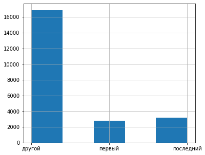

```python
data['floor_type'].hist(bins=5, figsize=(6, 5));
```

##### Общее количество этажей в доме

Построим гистограмму в соотношении с общим количеством этажей в доме.

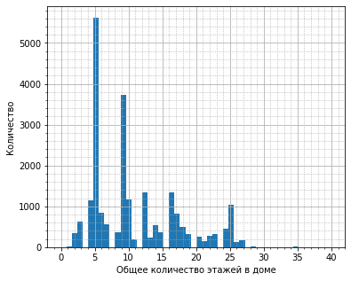

```python
data['floors_total'].hist(bins=50, figsize=(6, 5), range=(0, 40));
plt.minorticks_on()
plt.grid(which='minor', color='#aaa', ls=':')
plt.xlabel('Общее количество этажей в доме');
plt.ylabel('Количество');
```

На гистограмме можно выделить два больших пика. Первый и самый высокий пик характеризует количество квартир находящихся в пятиэтажных домах - около 5600. Второй пик - это девятиэтажные дома - около 3800.

##### Расстояние до центра города в метрах

Построим гистограмму, характеризующую растояние до центра города в метрах.

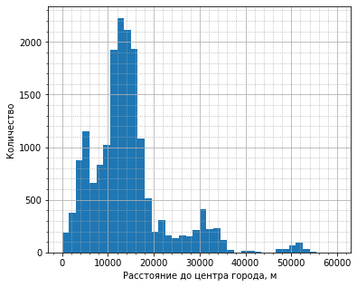

```python
data['cityCenters_nearest'].hist(bins=40, figsize=(6, 5), range=(0, 60000));
plt.minorticks_on()
plt.grid(which='minor', color='#aaa', ls=':')
plt.xlabel('Расстояние до центра города, м');
plt.ylabel('Количество');
```

##### Расстояние до ближайшего аэропорта

Построим гистограмму, характеризующую растояние до ближайшего аэропорта в метрах.

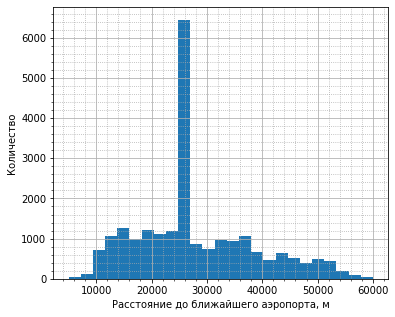

```python
data['airports_nearest'].hist(bins=25, figsize=(6, 5), range=(5000, 60000));
plt.minorticks_on()
plt.grid(which='minor', color='#aaa', ls=':')
plt.xlabel('Расстояние до ближайшего аэропорта, м');
plt.ylabel('Количество');
```

Самое большое количество квартир находятся на расстоянии около 26000 метров до аэропорта. С правой и с левой стороны от пика количество квартир распределены достаточно равномерно и колеблятся около 1000.

##### Расстояние до ближайшего парка

Построим гистограмму, характеризующую растояние до ближайшего парка в метрах.

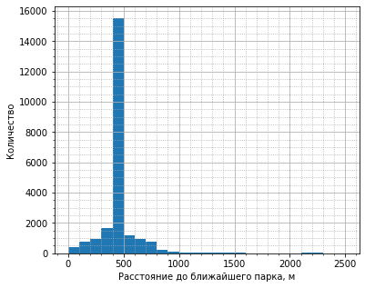

```python
data['parks_nearest'].hist(bins=25, figsize=(6, 5), range=(0, 2500));
plt.minorticks_on()
plt.grid(which='minor', color='#aaa', ls=':')
plt.xlabel('Расстояние до ближайшего парка, м');
plt.ylabel('Количество');
```

Самое большое количество квартир находятся на расстоянии около 500 метров до ближайшего парка. Количество квартир от 1000 метров и далее значительно уменьшается и стремится к 1.

##### День публикации объявления

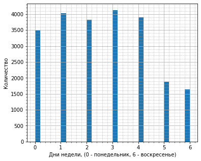

```python
data['week_day'].hist(bins=30, figsize=(6, 5), range=(0, 6));
plt.minorticks_on()
plt.grid(which='minor', color='#aaa', ls=':')
plt.xlabel('Дни недели, (0 - понедельник, 6 - воскресенье)');
plt.ylabel('Количество');
```

Количество объявлений в рабочие дни (пн - пт) - от 3000 до 4000, это в два раза больше, чем в выходные дни - около 2000.

##### Месяц публикации объявления

Построим гистограмму, характеризующую месяц публикации объявления.

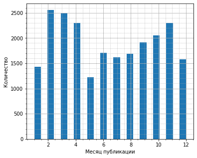

```python
data['month_publication'].hist(bins=23, figsize=(6, 5), range=(1, 12));
plt.minorticks_on()
plt.grid(which='minor', color='#aaa', ls=':')
plt.xlabel('Месяц публикации');
plt.ylabel('Количество');
```

Самое большое количество объявлений о продаже квартиры публикуется в феврале и марте - более 2500. Самое маленькое количество объявлений в мае - около 1250 публикаций.

#### Исследование о скорости продажи квартиры.

Столбец `days_exposition` показывает, сколько дней было размещено каждое объявление. В этом столбце остались пропуски, так как мы предположили, что если количество дней не указано, то квартира еще не продана.

Построим гистограмму для этого столбца.

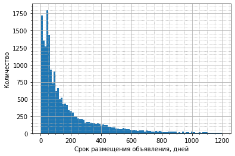

```python
data['days_exposition'].hist(bins=100);
plt.minorticks_on()
plt.grid(which='minor', color='#aaa', ls=':')
plt.xlabel('Срок размещения объявления, дней');
plt.ylabel('Количество');
```

На гистограмме мы можем увидеть, что достаточно большое количество квартир было продано за несколько дней. Объявления, которые были размещены на сайте более 1000 дней практически сливаются с 0. Необычно долгими продажами можно считать публикации, которые находятся на сайте более 800 дней.

```python
data['days_exposition'].describe()
```

```
count    19789.000000
mean       175.590934
std        205.982608
min          3.000000
25%         45.000000
50%         95.000000
75%        228.000000
max       1199.000000
Name: days_exposition, dtype: float64
```

Среднее значение количества дней продажи квартиры - 180. Медианное значение - 95 дней.

Создадим таблицу "sell_speed" - скорость продажи, которая будет включать столбец `locality_name` - название населенного пункта и `days_exposition`.

```python
# создадим отфильтрованную таблицу selling_speed
sell_speed = data[['locality_name', 'days_exposition']]
# отсортируем таблицу в порядке убывания по столбцу days_exposition
sell_speed.sort_values(by='days_exposition', ascending=False).head(10)
```

|  | locality_name | days_exposition |
| --- | --- | --- |
| 12889 | Санкт-Петербург | 1199.0 |
| 4344 | Санкт-Петербург | 1199.0 |
| 13821 | Пушкин | 1196.0 |
| 6332 | Санкт-Петербург | 1194.0 |
| 9640 | Молодёжное | 1194.0 |
| 23248 | Мурино | 1187.0 |
| 7091 | Кронштадт | 1183.0 |
| 12810 | Санкт-Петербург | 1182.0 |
| 17130 | Санкт-Петербург | 1181.0 |
| 763 | Санкт-Петербург | 1181.0 |

```
(-50.0, 600.0)
```

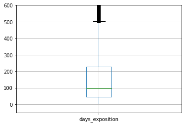

```python
# постороим диаграмму размаха
sell_speed.boxplot()
plt.ylim(-50, 600)
```

Можно увидеть, что большая часть значений лежит в диапазоне до 230 дней. При этом 1-ый квартиль лежит на уровне менее 50 дней. Объявления, которые были размещены на сайте менее 30 дней можно считать быстрыми.

**Вывод:** обычно время продажи квартиры занимает от 50 до 230 дней. Быстрыми продажами можно считать продажу квартиры менее 30 дней. Необычно долгими, если продажа занимает больше 800 дней.

#### Исследование факторов, которые больше всего влияют на стоимость квартиры

Исследуем как на полную стоимость объекта влияют: общая площадь, жилая площадь, площадь кухни, количество комнат, этаж на котором расположена квартира (первый, последний, другой) и дата размещения (день недели, месяц, год).

Для этого создадим новую таблицу - "sell_factors", включающую в себя следующие столбцы:

- `last_price` — цена на момент снятия с публикации;
- `total_area` — общая площадь квартиры в квадратных метрах (м²);
- `living_area` — жилая площадь в квадратных метрах (м²);
- `kitchen_area` — площадь кухни в квадратных метрах (м²);
- `rooms` — число комнат;
- `floor_type` - этаж на котором расположена квартира (первый, последний, другой);
- `week_day` - день недели публикации объявления;
- `month_publication` - месяц публикации объявления;
- `year_publication` - год публикации объявления.

```python
sell_factors_area = data[['last_price', 'total_area', 'living_area','kitchen_area']]
sell_factors_area.corr()
```

|  | last_price | total_area | living_area | kitchen_area |
| --- | --- | --- | --- | --- |
| last_price | 1.000000 | 0.737669 | 0.641674 | 0.555188 |
| total_area | 0.737669 | 1.000000 | 0.929777 | 0.593981 |
| living_area | 0.641674 | 0.929777 | 1.000000 | 0.376903 |
| kitchen_area | 0.555188 | 0.593981 | 0.376903 | 1.000000 |

Построим диаграмму рассеяния, и узнаем коэффициент корреляции для каждого из параметров.

##### Общая площадь квартиры

Узнаем, как сильно на полную стоимость объекта влияет общая площадь квартиры.

```
0.7376693934421465
```

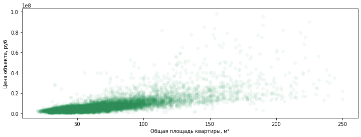

```python
x = sell_factors_area.total_area
y = sell_factors_area.last_price
fig, ax = plt.subplots()
ax.scatter(x, y, c='seagreen', alpha=0.05, marker = 'o', linewidths = 1,  edgecolors = 'mediumseagreen')
fig.set_figwidth(12)
fig.set_figwidth(12)
plt.xlabel('Общая площадь квартиры, м²')
plt.ylabel('Цена объекта, руб')
sell_factors_area['total_area'].corr(sell_factors_area['last_price'])
```

Коэффициент корреляции Пирсона равен 0,74. Наблюдается зависимость между стоимостью объекта и его площадью, чем больше площадь, тем выше стоимость.

##### Жилая площадь

Узнаем, как сильно на полную стоимость объекта влияет жилая площадь квартиры.

```
0.6416742951114435
```

[figure not shown]

```python
x = sell_factors_area.total_area
y = sell_factors_area.last_price
fig, ax = plt.subplots()
ax.scatter(x, y, c='mediumseagreen', alpha=0.05, marker = 'o', linewidths = 1,  edgecolors = 'seagreen')
fig.set_figwidth(12)
fig.set_figwidth(12)
plt.xlabel('Жилая площадь квартиры, м²')
plt.ylabel('Цена объекта, руб')
sell_factors_area['living_area'].corr(sell_factors_area['last_price'])
```

Коэффициент корреляции равен 0,64 - говорит о наличии связи между жилой площадью и стоимостью объекта. С увеличением жилой площади увеличивается общая стоимость ообъекта.

##### Площадь кухни

Узнаем, как сильно на полную стоимость объекта влияет площадь кухни.

```
0.5551884045528392
```

[figure not shown]

```python
x = sell_factors_area.total_area
y = sell_factors_area.last_price
fig, ax = plt.subplots()
ax.scatter(x, y, c='darkseagreen', alpha=0.05, marker = 'o', linewidths = 1,  edgecolors = 'seagreen')
fig.set_figwidth(12)
fig.set_figwidth(12)
plt.xlabel('Площадь кухни, м²')
plt.ylabel('Цена объекта, руб')
sell_factors_area['kitchen_area'].corr(sell_factors_area['last_price'])
```

Коэффициент корреляции равен 0,56. Такое значение коэффициента скорее говорит об наличии связи между площадью кухни и ценой объекта. С увеличением площади кухни увеличивается полная стоимость объекта.

##### Число комнат

Узнаем, влияет ли на полную стоимость квартиры число комнат.

Создадим сводную таблицу 'sell_factors_rooms'. Сгруппируем данные по количеству комнат, и рассчитаем медианное значение стоимости объектов.

```python
# создадим таблицу
sell_factors_rooms = data[['rooms', 'last_price']]
# рассчитаем коэффициент корреляции
sell_factors_rooms['rooms'].corr(sell_factors_rooms['last_price'])
```

```
0.4394482893239207
```

```python
# сгруппируем данные
sell_factors_rooms = sell_factors_rooms.groupby('rooms')['last_price'].median()
sell_factors_rooms.to_frame()
```

| rooms | last_price |
| --- | --- |
| 0 | 3095000.0 |
| 1 | 3600000.0 |
| 2 | 4750000.0 |
| 3 | 6180000.0 |
| 4 | 8950000.0 |
| 5 | 12900000.0 |
| 6 | 16490000.0 |

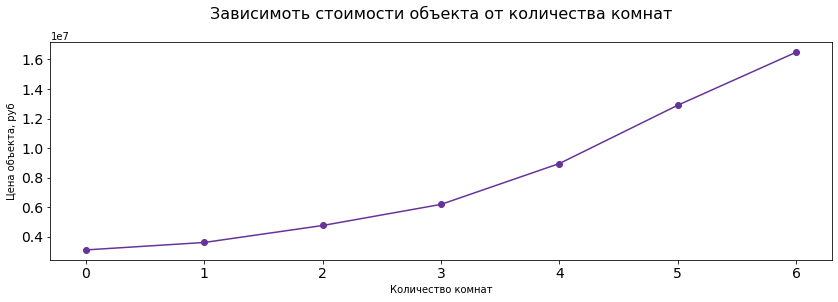

```python
(sell_factors_rooms
 .sort_values(ascending = True)
 .plot(style = 'o-', figsize = (14, 4), legend = False, fontsize = 14, c='rebeccapurple')
 .set_title('Зависимоть стоимости объекта от количества комнат' + "\n", fontsize = 16, color = 'k'));
plt.xlabel('Количество комнат');
plt.ylabel('Цена объекта, руб');
```

Коэффициент корреляции равен 0.44. На графике видно, что с увеличением количества комнат полная стоимость объекта увеличивается.

##### Этаж, на котором расположена квартира (первый, последний, другой)

Исследуем, как тип этажа квартиры влияет на ее стоимость.

Создадим сводную таблицу 'sell_factors_floor'. Сгруппируем данные по типу этажа (первый, последний, другой), и рассчитаем медианное значение стоимости объектов.

```python
sell_factors_floor = (data[['floor_type', 'last_price']]
                     .groupby('floor_type')['last_price'].median())
sell_factors_floor.to_frame()
```

| floor_type | last_price |
| --- | --- |
| другой | 4850000.0 |
| первый | 3900000.0 |
| последний | 4300000.0 |

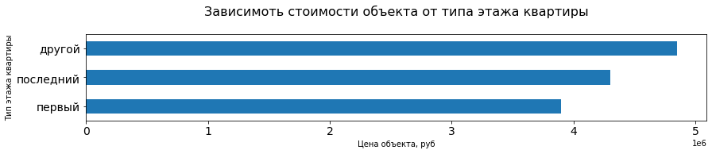

```python
(sell_factors_floor
 .sort_values(ascending = True)
 .plot(kind='barh', figsize = (14, 2), legend = False, fontsize = 14)
 .set_title('Зависимоть стоимости объекта от типа этажа квартиры' + "\n", fontsize = 16, color = 'k'));
plt.xlabel('Цена объекта, руб');
plt.ylabel('Тип этажа квартиры');
```

Стоимость квартир на первом этаже ниже, по сравнению со стоимотью квартир на последнем или другом этажах.

##### День недели публикации объявления

Узнаем, как день недели публикации влияет на полную стоимость квартиры.

Создадим сводную таблицу 'sell_factors_day_week'. Сгруппируем данные по дням недели, и рассчитаем медианное значение стоимости объектов.

```python
sell_factors_day_week = (data[['week_day', 'last_price']]
                         .groupby('week_day')['last_price'].median())
sell_factors_day_week.to_frame()
```

| week_day | last_price |
| --- | --- |
| 0 | 4650000.0 |
| 1 | 4750000.0 |
| 2 | 4700000.0 |
| 3 | 4640000.0 |
| 4 | 4580000.0 |
| 5 | 4550000.0 |
| 6 | 4550000.0 |

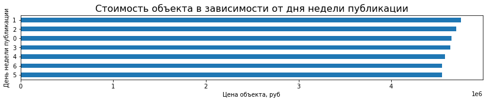

```python
(sell_factors_day_week
 .sort_values(ascending = True)
 .plot(kind='barh', figsize = (14, 2), legend = False, fontsize = 10)
 .set_title('Стоимость объекта в зависимости от дня недели публикации', fontsize = 16, color = 'k'));
plt.xlabel('Цена объекта, руб');
plt.ylabel('День недели публикации');
```

Стоимость объекта практически не менятся от дня недели публикации.

##### Месяц публикации объявления

Исследуем, как месяц публикации влияет на общую стоимость объекта.

Создадим сводную таблицу 'sell_factors_mounth'. Сгруппируем данные по месяцам, и рассчитаем медианное значение стоимости объектов.

```python
sell_factors_mounth = (data[['month_publication', 'last_price']]
                        .groupby('month_publication')['last_price'].median())
sell_factors_mounth.to_frame()
```

| month_publication | last_price |
| --- | --- |
| 1 | 4600000.0 |
| 2 | 4650000.0 |
| 3 | 4650000.0 |
| 4 | 4800000.0 |
| 5 | 4500000.0 |
| 6 | 4400000.0 |
| 7 | 4600000.0 |
| 8 | 4600000.0 |
| 9 | 4700000.0 |
| 10 | 4577500.0 |
| 11 | 4700000.0 |
| 12 | 4695000.0 |

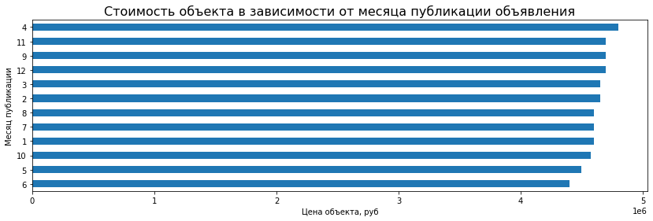

```python
(sell_factors_mounth
 .sort_values(ascending = True)
 .plot(kind='barh', figsize = (14, 4), legend = False, fontsize = 10)
 .set_title('Стоимость объекта в зависимости от месяца публикации объявления', fontsize = 16, color = 'k'));
plt.xlabel('Цена объекта, руб');
plt.ylabel('Месяц публикации');
```

Стоимость объекта практически не меняется от месяца публикации объявления.

##### Год публикации объявления

Исследуем, как год публикации объявления влияет на полную стоимость квартиры.

Создадим сводную таблицу 'sell_factors_year'. Сгруппируем данные по годам, и рассчитаем медианное значение стоимости объектов.

```python
# создадим таблицу
sell_factors_year = data[['year_publication', 'last_price']]
# рассчитаем коэффициент корреляции
sell_factors_year['year_publication'].corr(sell_factors_year['last_price'])
```

```
-0.042283488385751564
```

```python
# сгруппируем данные
sell_factors_year = sell_factors_year.groupby('year_publication')['last_price'].median()
sell_factors_year.to_frame()
```

| year_publication | last_price |
| --- | --- |
| 2014 | 7265000.0 |
| 2015 | 5200000.0 |
| 2016 | 4515000.0 |
| 2017 | 4500000.0 |
| 2018 | 4600000.0 |
| 2019 | 5050000.0 |

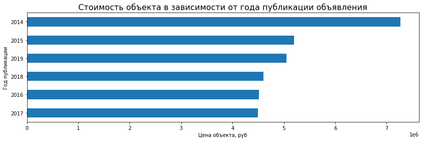

```python
(sell_factors_year
 .sort_values(ascending = True)
 .plot(kind='barh', figsize = (14, 4), legend = False, fontsize = 10)
 .set_title('Стоимость объекта в зависимости от года публикации объявления', fontsize = 16, color = 'k'));
plt.xlabel('Цена объекта, руб');
plt.ylabel('Год публикации');
```

#### Средняя стоимость одного квадратного метра в 10 населённых пунктах с наибольшим числом объявлений

Посчитаем среднюю цену одного квадратного метра в 10 населённых пунктах с наибольшим числом объявлений.

Создадим сводную таблицу "average_price_meter" - средняя цена одного квадратного метра, которая будет включать столбец `locality_name` - название населенного пункта, `price_square_meter` - цена одного квадратного метра.

```python
average_price_meter = (data[['locality_name', 'price_square_meter']]
                       .pivot_table(index='locality_name', values='price_square_meter',aggfunc=['count', 'mean'])
                       .sort_values(by=('count', 'price_square_meter'), ascending = False))
# дадим новые названия столбцов нашей сводной таблице:
# 'count_ads' - количество объявлений
# 'mean_price_sq_m' - средняя цена одного квадратного метра
average_price_meter.columns = ['count_ads', 'mean_price_sq_m']
# average_price_meter.style.format("{'mean_price_sq_m':,.2f}")
average_price_meter.head(10)
```

| locality_name | count_ads | mean_price_sq_m |
| --- | --- | --- |
| Санкт-Петербург | 15165 | 112857.961275 |
| Мурино | 547 | 85249.065505 |
| Кудрово | 443 | 94903.673597 |
| Шушары | 434 | 78356.385212 |
| Всеволожск | 389 | 68889.857574 |
| Пушкин | 358 | 102924.967733 |
| Колпино | 337 | 75333.295801 |
| Парголово | 325 | 90259.743484 |
| Гатчина | 307 | 68746.146763 |
| Выборг | 229 | 57979.595487 |

```python
# check
average_price_meter.head(10).style.format({"mean_price_sq_m" : "{:,.0f}"})
```

| locality_name | count_ads | mean_price_sq_m |
| --- | --- | --- |
| Санкт-Петербург | 15165 | 112,858 |
| Мурино | 547 | 85,249 |
| Кудрово | 443 | 94,904 |
| Шушары | 434 | 78,356 |
| Всеволожск | 389 | 68,890 |
| Пушкин | 358 | 102,925 |
| Колпино | 337 | 75,333 |
| Парголово | 325 | 90,260 |
| Гатчина | 307 | 68,746 |
| Выборг | 229 | 57,980 |

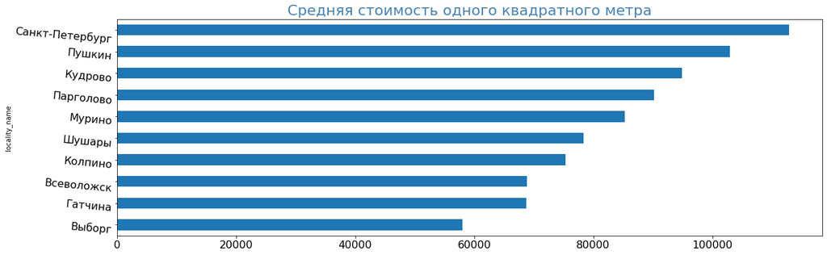

```python
(average_price_meter['mean_price_sq_m']
 .head(10)
 .sort_values(ascending = True)
 .plot(kind = 'barh', figsize = (19,6), rot = -5, legend = False, fontsize = 16)
 .set_title('Средняя стоимость одного квадратного метра', fontsize = 22, color = 'SteelBlue'));
```

Выделим населённые пункты с самой высокой и низкой стоимостью квадратного метра

```python
# выведем на экран название населенного пункта с самой высокой стоимостью квадратного метра
average_price_meter[average_price_meter['mean_price_sq_m'] == average_price_meter['mean_price_sq_m'].max()]
```

| locality_name | count_ads | mean_price_sq_m |
| --- | --- | --- |
| Зеленогорск | 24 | 115122.799198 |

```python
# выведем на экран название населенного пункта с самой низкой стоимостью квадратного метра
average_price_meter[average_price_meter['mean_price_sq_m'] == average_price_meter['mean_price_sq_m'].min()]
```

| locality_name | count_ads | mean_price_sq_m |
| --- | --- | --- |
| Малая Романовка | 1 | 12724.550898 |

Самая высокая стоимость квадратного метра в Зеленогорске - 115123 рублей.

#### Исследование, как стоимость объектов зависит от расстояния до центра города

Исследуем, как стоимость объектов зависит от растояния до центра. Для этого выделим квартиры с Санкт-Петербурге с помощью столбца `locality_name`.

Создадим новую таблицу `average_price_km` - средняя цена одного километра. Для этого нам понадобятся столбцы: `locality_name` - название населённого пункта, `last_price` - цена на момент снятия с публикации, `distance_to_center` - расстояние до центра города в километрах.

```python
# создадим новую таблицу 'average_price_km' и сделаем срез данных по Санкт-Петербургу
average_price_km = (data[['locality_name', 'distance_to_center', 'last_price']]
                    .query('locality_name == "Санкт-Петербург" and distance_to_center != 0'))
average_price_km.head(10)
```

|  | locality_name | distance_to_center | last_price |
| --- | --- | --- | --- |
| 0 | Санкт-Петербург | 16.0 | 13000000.0 |
| 2 | Санкт-Петербург | 14.0 | 5196000.0 |
| 3 | Санкт-Петербург | 7.0 | 64900000.0 |
| 4 | Санкт-Петербург | 8.0 | 10000000.0 |
| 7 | Санкт-Петербург | 12.0 | 7915000.0 |
| 9 | Санкт-Петербург | 15.0 | 5400000.0 |
| 10 | Санкт-Петербург | 14.0 | 5050000.0 |
| 15 | Санкт-Петербург | 14.0 | 4650000.0 |
| 16 | Санкт-Петербург | 11.0 | 6700000.0 |
| 17 | Санкт-Петербург | 15.0 | 4180000.0 |

```python
# Добавим новый столбец price_km - цена одного километра.
#average_price_km['price_km'] = average_price_km['last_price'] / average_price_km['distance_to_center']
#average_price_km.head()
```

Создадим сводную таблицу, в которой сгруппируем данные по столбцу `distance_to_center` - расстояние до центра города, и посчитаем среднюю стоимость объектов.

```python
# создадим сводную таблицу и отсортируе ее в порядке возрастания расстояния до центра
average_price_km = (average_price_km
                    .pivot_table(index='distance_to_center', values=['last_price'], aggfunc='mean')
                    .sort_values(by='distance_to_center'))
# изменим название столбца
# 'av_price_km' - средняя цена одного километра
average_price_km.columns = ['average_price']
average_price_km
```

| distance_to_center | average_price |
| --- | --- |
| 1.0 | 1.362927e+07 |
| 2.0 | 1.424546e+07 |
| 3.0 | 1.021677e+07 |
| 4.0 | 1.097177e+07 |
| 5.0 | 1.174191e+07 |
| 6.0 | 1.200840e+07 |
| 7.0 | 1.351154e+07 |
| 8.0 | 8.897210e+06 |
| 9.0 | 6.928372e+06 |
| 10.0 | 6.417604e+06 |
| 11.0 | 6.150795e+06 |
| 12.0 | 5.814255e+06 |
| 13.0 | 6.080563e+06 |
| 14.0 | 5.611384e+06 |
| 15.0 | 5.797912e+06 |
| 16.0 | 5.382055e+06 |
| 17.0 | 5.249745e+06 |
| 18.0 | 4.941723e+06 |
| 19.0 | 5.080331e+06 |
| 20.0 | 6.041102e+06 |
| 21.0 | 5.505146e+06 |
| 22.0 | 5.415524e+06 |
| 23.0 | 4.884434e+06 |
| 24.0 | 3.890687e+06 |
| 25.0 | 4.255914e+06 |
| 26.0 | 4.142486e+06 |
| 27.0 | 8.300000e+06 |
| 28.0 | 5.026429e+06 |
| 29.0 | 4.236667e+06 |

Добавим к нашей таблице столбец `distance` со значениями расстояния до центра. Для этого создадим список `list_distance`, со всеми всеми значениями столбца `distance_to_center`.

```python
# создаем список 'list_distance'
list_distance = [1, 2, 3, 4, 5, 6, 7, 8, 9, 10, 11, 12, 13, 14, 15, 16,\
                 17, 18, 19, 20, 21, 22, 23, 24, 25, 26, 27, 28, 29]
```

```python
# добавляем столбец 'distance' к сводной таблице 'average_price_km'
average_price_km['distance'] = list_distance
average_price_km
```

| distance_to_center | average_price | distance |
| --- | --- | --- |
| 1.0 | 1.362927e+07 | 1 |
| 2.0 | 1.424546e+07 | 2 |
| 3.0 | 1.021677e+07 | 3 |
| 4.0 | 1.097177e+07 | 4 |
| 5.0 | 1.174191e+07 | 5 |
| 6.0 | 1.200840e+07 | 6 |
| 7.0 | 1.351154e+07 | 7 |
| 8.0 | 8.897210e+06 | 8 |
| 9.0 | 6.928372e+06 | 9 |
| 10.0 | 6.417604e+06 | 10 |
| 11.0 | 6.150795e+06 | 11 |
| 12.0 | 5.814255e+06 | 12 |
| 13.0 | 6.080563e+06 | 13 |
| 14.0 | 5.611384e+06 | 14 |
| 15.0 | 5.797912e+06 | 15 |
| 16.0 | 5.382055e+06 | 16 |
| 17.0 | 5.249745e+06 | 17 |
| 18.0 | 4.941723e+06 | 18 |
| 19.0 | 5.080331e+06 | 19 |
| 20.0 | 6.041102e+06 | 20 |
| 21.0 | 5.505146e+06 | 21 |
| 22.0 | 5.415524e+06 | 22 |
| 23.0 | 4.884434e+06 | 23 |
| 24.0 | 3.890687e+06 | 24 |
| 25.0 | 4.255914e+06 | 25 |
| 26.0 | 4.142486e+06 | 26 |
| 27.0 | 8.300000e+06 | 27 |
| 28.0 | 5.026429e+06 | 28 |
| 29.0 | 4.236667e+06 | 29 |

Построим график зависимости средней стоимости квартиры от расстояния до центра города Санкт-Петербурга.

```
-0.80439057362244
```

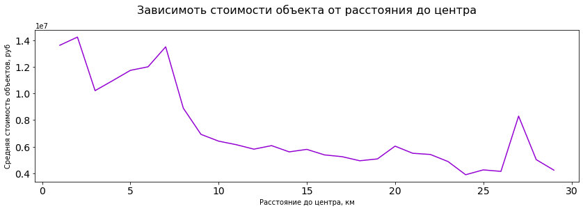

```python
(average_price_km
 .plot(x = 'distance', y = 'average_price', style = '-', figsize = (14, 4), legend = False, fontsize = 14, c='darkviolet')
 .set_title('Зависимоть стоимости объекта от расстояния до центра' + "\n", fontsize = 16, color = 'k'));
plt.xlabel('Расстояние до центра, км');
plt.ylabel('Средняя стоимость объектов, руб');
average_price_km['distance'].corr(average_price_km['average_price'])
```

**Вывод:** средняя цена одного километра зависит от расстояния до центра. Чем ближе к центру расположена квартира, тем дороже ее стоимость.

### Общий вывод

**На этапе предобработки данных мы проделали следующую работу:**

1. Удалили или заполнили пропуски в следующих столбцах:
- Удалили строки с пропусками в столбцах `floors_total` и `locality_name`.
- Пропуски, обнаруженные в столбце `is_apartment` заполнили булевым значением False.
- Пропуски в столбцах `balcony`, `parks_around3000` и `ponds_around3000` заполнили значением "0".
- Пропуски в столбцах `living_area` и `kitchen_area` заполнили исходя из общей площади столбца `total_area`.
- Пропуски в столбцах `airports_nearest`, `cityCenters_nearest`, `parks_nearest`, `ponds_nearest` - заполним медианными значениями по каждому типу из столбца `locality_name`, а оставшиеся пропуски заполнили медианными значениями каждого столбца.
1. Обработали неявные дубликаты в столбце `locality_name` - название населённого пункта.
2. Заменили вещественный тип данных в столбцах `floors_total` и `balcony` на целочисленный. Столбец `first_day_exposition` - дата публикации, перевели в формат даты.
3. Обработали аномальные и редкие значения в столбцах `ceiling_height`,`rooms`, `last_price`, `living_area`, `kitchen_area`, `total_area`, `floors_total`, и `days_exposition` .
4. Добавили новые столбцы:
- `price_square_meter` - цена одного квадратного метра;
- `week_day` - день недели публикации объявления;
- `month_publication` - месяц публикации объявления;
- `year_publication` - год публикации объявления;
- `floor_type` - тип этажа квартиры (значения — «первый», «последний», «другой»);
- `distance_to_center` - расстояние до центра города в километрах.

**Рекомендуем обратить внимание на сбор данных, которые были получены автоматически на основе картографических данных, так как много данных было утеряно и столбцы содержали пропущенные значения.**